# QTM 151 Final Project: How did countries around the world respond to COVID-19?

## COVID-19 and the Rights to Health and Education - Income and Region Analysis

# Initial Exploration to Understand the Data

We used esr_hiy_globalbest.csv and esr_lmy_globalbest.csv, which contain data about the economic and social rights for high and low/middle income countries using the "global best" standard of assessment.

We knew we wanted to explore COVID-19, so we cleaned and analyzed the data to find the best rights to work with based on the number of "valid" high and low/middle income countries for each GBScore right. We defined a "valid country" as having data for pre-COVID (2019), during COVID (2020), and post-COVID/recovery period (2021) for that specific right.

Upon completion of this exploratory phase, we decided to focus on health and education, as these rights had the most number of "valid" high income countries (there were much fewer high than low/middle income countries).

## ESR Datasets

```python
import pandas as pd
import numpy as np
import matplotlib.pyplot as plt
import seaborn as sns
# from google.colab import drive
# drive.mount('/content/drive')
```

```python
esr_hiy_globalbest = pd.read_csv("csv files/esr_hiy_globalbest.csv")
esr_lmy_globalbest = pd.read_csv("csv files/esr_lmy_globalbest.csv")
```

```python
print("High Income global best Dataset")
print(esr_hiy_globalbest.columns)
```

```
High Income global best Dataset
Index(['Country_Code', 'Country', 'High_Income_Country', 'Year',
       'HiY_QofL_All_GBScore', 'HiY_Education_All_GBScore',
       'HiY_Food_All_GBScore', 'HiY_Health_All_GBScore',
       'HiY_Housing_All_GBScore', 'HiY_Work_All_GBScore',
       'PISAmath_All_MRYear', 'PISAmath_All_MRGDP', 'PISAmath_All_MRValue',
       'PISAmath_All_GBPenalty', 'PISAmath_All_GBScore',
       'PISAreading_All_MRYear', 'PISAreading_All_MRGDP',
       'PISAreading_All_MRValue', 'PISAreading_All_GBPenalty',
       'PISAreading_All_GBScore', 'PISAscience_All_MRYear',
       'PISAscience_All_MRGDP', 'PISAscience_All_MRValue',
       'PISAscience_All_GBPenalty', 'PISAscience_All_GBScore',
       'HiY_PISAAverage_All_GBScore', 'TotNetUpSecEn_All_MRYear',
       'TotNetUpSecEn_All_MRGDP', 'TotNetUpSecEn_All_MRValue',
       'TotNetUpSecEn_All_GBPenalty', 'TotNetUpSecEn_All_GBScore',
       'FoodSecure_All_MRYear', 'FoodSecure_All_MRGDP',
       'FoodSecure_All_MRValue', 'FoodSecure_All_GBPenalty',
       'FoodSecure_All_GBScore', 'NotLowBirWt_MRYear', 'NotLowBirWt_MRGDP',
       'NotLowBirWt_MRValue', 'NotLowBirWt_GBPenalty', 'NotLowBirWt_GBScore',
       'SeniorSurvival_All_MRYear', 'SeniorSurvival_All_MRGDP',
       'SeniorSurvival_All_MRValue', 'SeniorSurvival_All_GBPenalty',
       'SeniorSurvival_All_GBScore', 'U5Survival_All_MRYear',
       'U5Survival_All_MRGDP', 'U5Survival_All_MRValue',
       'U5Survival_All_GBPenalty', 'U5Survival_All_GBScore',
       'AffordHouse_MRYear', 'AffordHouse_MRGDP', 'AffordHouse_MRValue',
       'AffordHouse_GBPenalty', 'AffordHouse_GBScore', 'SafeSanitation_MRYear',
       'SafeSanitation_MRGDP', 'SafeSanitation_MRValue',
       'SafeSanitation_GBPenalty', 'SafeSanitation_GBScore',
       'NotLTUnemploy_All_MRYear', 'NotLTUnemploy_All_MRGDP',
       'NotLTUnemploy_All_MRValue', 'NotLTUnemploy_All_GBPenalty',
       'NotLTUnemploy_All_GBScore', 'NotRelPoor_MRYear', 'NotRelPoor_MRGDP',
       'NotRelPoor_MRValue', 'NotRelPoor_GBPenalty', 'NotRelPoor_GBScore'],
      dtype='object')
```

```python
print("First rows of high income global best Dataset")
print(esr_hiy_globalbest.head())
```

```
First rows of high income global best Dataset
  Country_Code Country  High_Income_Country  Year  HiY_QofL_All_GBScore  \
0          ABW   Aruba                    1  1990                   NaN
1          ABW   Aruba                    1  1991                   NaN
2          ABW   Aruba                    1  1992                   NaN
3          ABW   Aruba                    1  1993                   NaN
4          ABW   Aruba                    1  1994                   NaN

   HiY_Education_All_GBScore  HiY_Food_All_GBScore  HiY_Health_All_GBScore  \
0                        NaN                   NaN                     NaN
1                        NaN                   NaN                     NaN
2                        NaN                   NaN                     NaN
3                        NaN                   NaN                     NaN
4                        NaN                   NaN                     NaN

```

[output cut: 36 more lines]

```python
print("Columns in low-middle-income global best Dataset")
print(esr_lmy_globalbest.columns)
```

```
Columns in low-middle-income global best Dataset
Index(['Country_Code', 'Country', 'High_Income_Country', 'Year',
       'LMY_QofL_All_GBScore', 'LMY_Education_All_GBScore',
       'LMY_Food_All_GBScore', 'LMY_Health_All_GBScore',
       'LMY_Housing_All_GBScore', 'LMY_Work_All_GBScore',
       'H_EducQual_All_MRYear', 'H_EducQual_All_MRGDP',
       'H_EducQual_All_MRValue', 'H_EducQual_All_GBPenalty',
       'H_EducQual_All_GBScore', 'TotNetPrimEn_All_MRYear',
       'TotNetPrimEn_All_MRGDP', 'TotNetPrimEn_All_MRValue',
       'TotNetPrimEn_All_GBPenalty', 'TotNetPrimEn_All_GBScore',
       'TotNetUpSecEn_All_MRYear', 'TotNetUpSecEn_All_MRGDP',
       'TotNetUpSecEn_All_MRValue', 'TotNetUpSecEn_All_GBPenalty',
       'TotNetUpSecEn_All_GBScore', 'NotStunted_All_MRYear',
       'NotStunted_All_MRGDP', 'NotStunted_All_MRValue',
       'NotStunted_All_GBPenalty', 'NotStunted_All_GBScore',
       'AdultSurvival_All_MRYear', 'AdultSurvival_All_MRGDP',
       'AdultSurvival_All_MRValue', 'AdultSurvival_All_GBPenalty',
       'AdultSurvival_All_GBScore', 'Contraception_MRYear',
       'Contraception_MRGDP', 'Contraception_MRValue',
       'Contraception_GBPenalty', 'Contraception_GBScore',
       'U5Survival_All_MRYear', 'U5Survival_All_MRGDP',
       'U5Survival_All_MRValue', 'U5Survival_All_GBPenalty',
       'U5Survival_All_GBScore', 'BasicSanitation_MRYear',
       'BasicSanitation_MRGDP', 'BasicSanitation_MRValue',
       'BasicSanitation_GBPenalty', 'BasicSanitation_GBScore',
       'WaterInHome_MRYear', 'WaterInHome_MRGDP', 'WaterInHome_MRValue',
       'WaterInHome_GBPenalty', 'WaterInHome_GBScore', 'NotAbsPoor_MRYear',
       'NotAbsPoor_MRGDP', 'NotAbsPoor_MRValue', 'NotAbsPoor_GBPenalty',
       'NotAbsPoor_GBScore'],
      dtype='object')
```

#### Notes on ESR Columns

For health analysis we have several important metrics:

###### In High Income Countries (esr_hiy_globalbest):

HiY_Health_All_GBScore - Overall health score SeniorSurvival_All_MRValue - Senior survival rates U5Survival_All_MRValue - Under-5 survival rates NotLowBirWt_MRValue - Not low birth weight rates

###### In Low-Middle Income Countries (esr_lmy_globalbest):

LMY_Health_All_GBScore - Overall health score AdultSurvival_All_MRValue - Adult survival rates U5Survival_All_MRValue - Under-5 survival rates Contraception_MRValue - Contraception access

### Years in ESR Dataset

```python
print("\nYears in high-income dataset:")
print(esr_hiy_globalbest['Year'].unique())
print("\nYears in low-middle-income dataset:")
print(esr_lmy_globalbest['Year'].unique())
```

```
Years in high-income dataset:
[1990 1991 1992 1993 1994 1995 1996 1997 1998 1999 2000 2001 2002 2003
 2004 2005 2006 2007 2008 2009 2010 2011 2012 2013 2014 2015 2016 2017
 2018 2019 2020 2021]

Years in low-middle-income dataset:
[1990 1991 1992 1993 1994 1995 1996 1997 1998 1999 2000 2001 2002 2003
 2004 2005 2006 2007 2008 2009 2010 2011 2012 2013 2014 2015 2016 2017
 2018 2019 2020 2021]
```

### Quality of Life Exploration

```python
#exploring quality of life score
high_income_countries = esr_hiy_globalbest[esr_hiy_globalbest['High_Income_Country'] == 1]['Country'].unique()
low_income_countries = esr_lmy_globalbest[esr_lmy_globalbest['High_Income_Country'] == 0]['Country'].unique()

print("Number of high-income countries:", len(high_income_countries))
print("Number of low-income countries:", len(low_income_countries))

# Classifyingcountries, using Quality of Life score (QofL) / not the GDP

# For high-income countries
top_high_income = esr_hiy_globalbest[esr_hiy_globalbest['High_Income_Country'] == 1].groupby('Country')['HiY_QofL_All_GBScore'].mean().sort_values(ascending=False).head(10)

print("\nTop 10 High-Income Countries by Quality of Life Score:")
print(top_high_income)

# For low-income countries
bottom_income = esr_lmy_globalbest[esr_lmy_globalbest['High_Income_Country'] == 0].groupby('Country')['LMY_QofL_All_GBScore'].mean().sort_values(ascending=True).head(10)

print("\nBottom 10 Countries by Quality of Life Score:")
print(bottom_income)
```

```
Number of high-income countries: 83
Number of low-income countries: 139

Top 10 High-Income Countries by Quality of Life Score:
Country
Finland           85.308687
Poland            83.019391
Sweden            82.938374
Czechia           80.476366
Estonia           80.473837
United Kingdom    80.280981
Netherlands       79.975679
Belgium           79.940972
France            79.905390
Austria           79.885596
Name: HiY_QofL_All_GBScore, dtype: float64

Bottom 10 Countries by Quality of Life Score:
Country
Niger                       30.003212
Central African Republic    31.739911
Chad                        35.274631
Madagascar                  35.666077
Burundi                     35.983620
Malawi                      40.060831
Mozambique                  40.254430
Burkina Faso                41.688183
Ethiopia                    41.860375
Papua New Guinea            41.907402
Name: LMY_QofL_All_GBScore, dtype: float64
```

## Data Cleaning to Choose Rights

Find the number of valid high income countries (*high_income_countries*) and low and middle income countries (*low_income_countries*) for each GBScore category. A valid country is one that has data for all three years of **2019, 2020, and 2021** for a specific GBScore right (Quality of Living, Education, Food, Health, Housing, Work).

### First: high income countries

```python
# Data for all high income countries during 2019, 2020, 2021
high_income_countries = esr_hiy_globalbest[esr_hiy_globalbest['High_Income_Country'] == 1]['Country'].unique()
high_income_covid = esr_hiy_globalbest[(esr_hiy_globalbest['Country'].isin(high_income_countries)) &
                                             (esr_hiy_globalbest['Year'].isin([2019, 2020, 2021]))]

# Focus on GBScores for QofL, Education, Food, Health, Housing, Work
GBScores_high = ['HiY_QofL_All_GBScore', 'HiY_Education_All_GBScore', 'HiY_Food_All_GBScore',
            'HiY_Health_All_GBScore', 'HiY_Housing_All_GBScore', 'HiY_Work_All_GBScore']
high_income_covid_rights = high_income_covid[['Country_Code', 'Country', 'High_Income_Country', 'Year'] + GBScores_high]

# Filter: all countries with missing data for all rights categories over ANY years of interest
# In case we want to look at all three years - we can't use a country that has no data for a year
high_income_missing = high_income_covid_rights.groupby(['Country', 'Year'])[GBScores_high].apply(lambda x: x.isna().all().all())
high_income_missing_countries = high_income_missing[high_income_missing].reset_index()['Country'].unique()
high_income_valid = high_income_missing[~high_income_missing].reset_index()['Country'].unique()
print('Unusable Countries')
print(high_income_missing_countries)
print('Valid Countries')
print(high_income_valid)
high_income_covid_rights_filtered = high_income_covid_rights[high_income_covid_rights['Country'].isin(high_income_valid)]
```

```
Unusable Countries
['Andorra' 'Aruba' 'Barbados' 'Bermuda' 'British Virgin Islands'
 'Cayman Islands' 'Channel Islands' 'Cook Islands' 'Curacao'
 'Faroe Islands' 'French Polynesia' 'Gibraltar' 'Greenland' 'Guam'
 'Isle of Man' 'Liechtenstein' 'Monaco' 'New Caledonia' 'Niue'
 'Northern Mariana Islands' 'Puerto Rico' 'Saudi Arabia'
 'Sint Maarten (Dutch part)' 'St. Martin (French part)'
 'Turks and Caicos Islands' 'Virgin Islands (U.S.)']
Valid Countries
['Antigua and Barbuda' 'Australia' 'Austria' 'Bahamas, The' 'Bahrain'
 'Barbados' 'Belgium' 'Brunei Darussalam' 'Canada' 'Chile' 'Croatia'
 'Cyprus' 'Czechia' 'Denmark' 'Estonia' 'Finland' 'France' 'Germany'
 'Greece' 'Hong Kong SAR, China' 'Hungary' 'Iceland' 'Ireland' 'Israel'
 'Italy' 'Japan' 'Korea, Rep.' 'Kuwait' 'Latvia' 'Lithuania' 'Luxembourg'
 'Macao SAR, China' 'Malta' 'Nauru' 'Netherlands' 'New Zealand' 'Norway'
 'Oman' 'Panama' 'Poland' 'Portugal' 'Qatar' 'Romania' 'San Marino'
 'Seychelles' 'Singapore' 'Slovak Republic' 'Slovenia' 'Spain'
 'St. Kitts and Nevis' 'Sweden' 'Switzerland' 'Taiwan'
 'Trinidad and Tobago' 'United Arab Emirates' 'United Kingdom'
 'United States' 'Uruguay']
```

```python
# For each right, count the number of countries that have complete data (it has data for all years for that right)
# Dictionary to store results
complete_counts_high = {}
# Loop through each rights column
for right in GBScores_high:
    # Group by country, check if all years have non-missing values for that right
    complete_per_country = high_income_covid_rights_filtered.groupby('Country')[right].apply(lambda x: x.notna().all())
    # Count how many countries have complete data (i.e., True)
    complete_counts_high[right] = complete_per_country.sum()
# Print results
high_income_country_counts_rights = pd.DataFrame(list(complete_counts_high.items()), columns=['HiY Right', 'HiY Num_Countries_Complete'])
print(high_income_country_counts_rights)

# Find proportion of all valid high income countries for each right
high_income_country_counts_rights['HiY Prop_Countries_Complete'] = high_income_country_counts_rights['HiY Num_Countries_Complete']/len(high_income_valid)
```

```
                   HiY Right  HiY Num_Countries_Complete
0       HiY_QofL_All_GBScore                          27
1  HiY_Education_All_GBScore                          48
2       HiY_Food_All_GBScore                          42
3     HiY_Health_All_GBScore                          53
4    HiY_Housing_All_GBScore                          29
5       HiY_Work_All_GBScore                          36
```

### Next: low and middle income countries

```python
# Data for all low income countries during 2019, 2020, 2021
low_income_countries = esr_lmy_globalbest[esr_lmy_globalbest['High_Income_Country'] == 0]['Country'].unique()
low_income_covid = esr_lmy_globalbest[(esr_lmy_globalbest['Country'].isin(low_income_countries)) &
                                             (esr_lmy_globalbest['Year'].isin([2019, 2020, 2021]))]

# Focus on GBScores for QofL, Education, Food, Health, Housing, Work
GBScores_low = ['LMY_QofL_All_GBScore', 'LMY_Education_All_GBScore', 'LMY_Food_All_GBScore',
            'LMY_Health_All_GBScore', 'LMY_Housing_All_GBScore', 'LMY_Work_All_GBScore']
low_income_covid_rights = low_income_covid[['Country_Code', 'Country', 'High_Income_Country', 'Year'] + GBScores_low]

# Filter: all countries with missing data for all rights categories over ANY years of interest
# In case we want to look at all three years - we can't use a country that has no data for a year
low_income_missing = low_income_covid_rights.groupby(['Country', 'Year'])[GBScores_low].apply(lambda x: x.isna().all().all())
low_income_missing_countries = low_income_missing[low_income_missing].reset_index()['Country'].unique()
low_income_valid = low_income_missing[~low_income_missing].reset_index()['Country'].unique()
print('Unusable Countries')
print(low_income_missing_countries)
print('Valid Countries')
print(low_income_valid)
low_income_covid_rights_filtered = low_income_covid_rights[low_income_covid_rights['Country'].isin(low_income_valid)]
```

```
Unusable Countries
['American Samoa' 'Cuba' 'Eritrea' "Korea, Dem. People's Rep."
 'South Sudan' 'Syrian Arab Republic' 'Tokelau' 'Venezuela, RB'
 'Wallis and Futuna Islands' 'Yemen, Rep.']
Valid Countries
['Afghanistan' 'Albania' 'Algeria' 'Angola' 'Argentina' 'Armenia'
 'Azerbaijan' 'Bangladesh' 'Belarus' 'Belize' 'Benin' 'Bhutan' 'Bolivia'
 'Bosnia and Herzegovina' 'Botswana' 'Brazil' 'Bulgaria' 'Burkina Faso'
 'Burundi' 'Cabo Verde' 'Cambodia' 'Cameroon' 'Central African Republic'
 'Chad' 'China' 'Colombia' 'Comoros' 'Congo, Dem. Rep.' 'Congo, Rep.'
 'Costa Rica' "Cote d'Ivoire" 'Djibouti' 'Dominica' 'Dominican Republic'
 'Ecuador' 'Egypt, Arab Rep.' 'El Salvador' 'Equatorial Guinea' 'Eswatini'
 'Ethiopia' 'Fiji' 'Gabon' 'Gambia, The' 'Georgia' 'Ghana' 'Grenada'
 'Guatemala' 'Guinea' 'Guinea-Bissau' 'Guyana' 'Haiti' 'Honduras' 'India'
 'Indonesia' 'Iran, Islamic Rep.' 'Iraq' 'Jamaica' 'Jordan' 'Kazakhstan'
 'Kenya' 'Kiribati' 'Kosovo' 'Kyrgyz Republic' 'Lao PDR' 'Lebanon'
 'Lesotho' 'Liberia' 'Libya' 'Madagascar' 'Malawi' 'Malaysia' 'Maldives'
 'Mali' 'Marshall Islands' 'Mauritania' 'Mauritius' 'Mexico'
 'Micronesia, Fed. Sts.' 'Moldova' 'Mongolia' 'Montenegro' 'Morocco'
 'Mozambique' 'Myanmar' 'Namibia' 'Nepal' 'Nicaragua' 'Niger' 'Nigeria'
 'North Macedonia' 'Pakistan' 'Palau' 'Papua New Guinea' 'Paraguay' 'Peru'
 'Philippines' 'Russian Federation' 'Rwanda' 'Samoa'
 'Sao Tome and Principe' 'Senegal' 'Serbia' 'Sierra Leone'
 'Solomon Islands' 'Somalia' 'South Africa' 'Sri Lanka' 'St. Lucia'
 'St. Vincent and the Grenadines' 'Sudan' 'Suriname' 'Tajikistan'
 'Tanzania' 'Thailand' 'Timor-Leste' 'Togo' 'Tonga' 'Tunisia' 'Turkiye'
 'Turkmenistan' 'Tuvalu' 'Uganda' 'Ukraine' 'Uzbekistan' 'Vanuatu'
 'Viet Nam' 'West Bank and Gaza' 'Zambia' 'Zimbabwe']
```

```python
# For each right, count the number of countries that have complete data (it has data for all years for that right)
# Dictionary to store results
complete_counts_low = {}
# Loop through each rights column
for right in GBScores_low:
    # Group by country, check if all years have non-missing values for that right
    complete_per_country = low_income_covid_rights_filtered.groupby('Country')[right].apply(lambda x: x.notna().all())
    # Count how many countries have complete data (i.e., True)
    complete_counts_low[right] = complete_per_country.sum()
# Print results
low_income_country_counts_rights = pd.DataFrame(list(complete_counts_low.items()), columns=['LMY Right', 'LMY Num_Countries_Complete'])
print(low_income_country_counts_rights)

# Find proportion of all valid low/middle income countries for each right
low_income_country_counts_rights['LMY Prop_Countries_Complete'] = low_income_country_counts_rights['LMY Num_Countries_Complete']/len(low_income_valid)
```

```
                   LMY Right  LMY Num_Countries_Complete
0       LMY_QofL_All_GBScore                          76
1  LMY_Education_All_GBScore                          93
2       LMY_Food_All_GBScore                         114
3     LMY_Health_All_GBScore                         117
4    LMY_Housing_All_GBScore                         128
5       LMY_Work_All_GBScore                         108
```

### Visualize both together:

|  | HiY Right | HiY Num_Countries_Complete | HiY Prop_Countries_Complete | Right | LMY Right | LMY Num_Countries_Complete | LMY Prop_Countries_Complete |
| --- | --- | --- | --- | --- | --- | --- | --- |
| 0 | HiY_QofL_All_GBScore | 27 | 0.465517 | Quality of Life | LMY_QofL_All_GBScore | 76 | 0.589147 |
| 1 | HiY_Education_All_GBScore | 48 | 0.827586 | Education | LMY_Education_All_GBScore | 93 | 0.720930 |
| 2 | HiY_Food_All_GBScore | 42 | 0.724138 | Food | LMY_Food_All_GBScore | 114 | 0.883721 |
| 3 | HiY_Health_All_GBScore | 53 | 0.913793 | Health | LMY_Health_All_GBScore | 117 | 0.906977 |
| 4 | HiY_Housing_All_GBScore | 29 | 0.500000 | Housing | LMY_Housing_All_GBScore | 128 | 0.992248 |
| 5 | HiY_Work_All_GBScore | 36 | 0.620690 | Work | LMY_Work_All_GBScore | 108 | 0.837209 |

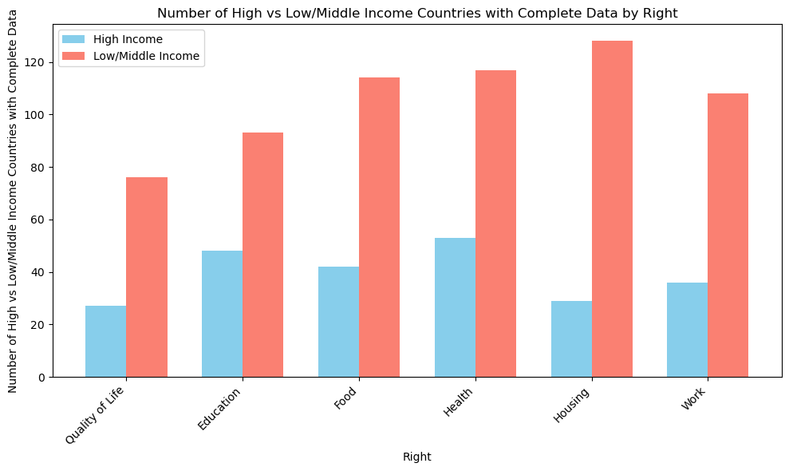

```python
# Add 'right' column to high and low income country counts dataframes
right = ['Quality of Life', 'Education', 'Food', 'Health', 'Housing', 'Work']
high_income_country_counts_rights['Right'] = right
low_income_country_counts_rights['Right'] = right

# Merge high and low income
country_counts_rights = pd.merge(high_income_country_counts_rights, low_income_country_counts_rights, on = ['Right'])
display(country_counts_rights)

# Visualize counts
# Number of categories
x = np.arange(len(country_counts_rights['Right']))  # x positions for the categories
width = 0.35  # Bar width for each group

# Plotting the two-bar grouped bar plot
fig, ax = plt.subplots(figsize=(10, 6))

# Create bars for both groups
bars1 = ax.bar(x - width/2, country_counts_rights['HiY Num_Countries_Complete'], width, label='High Income', color='skyblue')
bars2 = ax.bar(x + width/2, country_counts_rights['LMY Num_Countries_Complete'], width, label='Low/Middle Income', color='salmon')

# Labels and title
ax.set_xlabel('Right')
ax.set_ylabel('Number of High vs Low/Middle Income Countries with Complete Data')
ax.set_title('Number of High vs Low/Middle Income Countries with Complete Data by Right')

# Set x-ticks and labels
ax.set_xticks(x)
ax.set_xticklabels(country_counts_rights['Right'], rotation=45, ha='right')

# Add a legend
ax.legend()

# Layout adjustment
plt.tight_layout()

# Show the plot
plt.show()
```

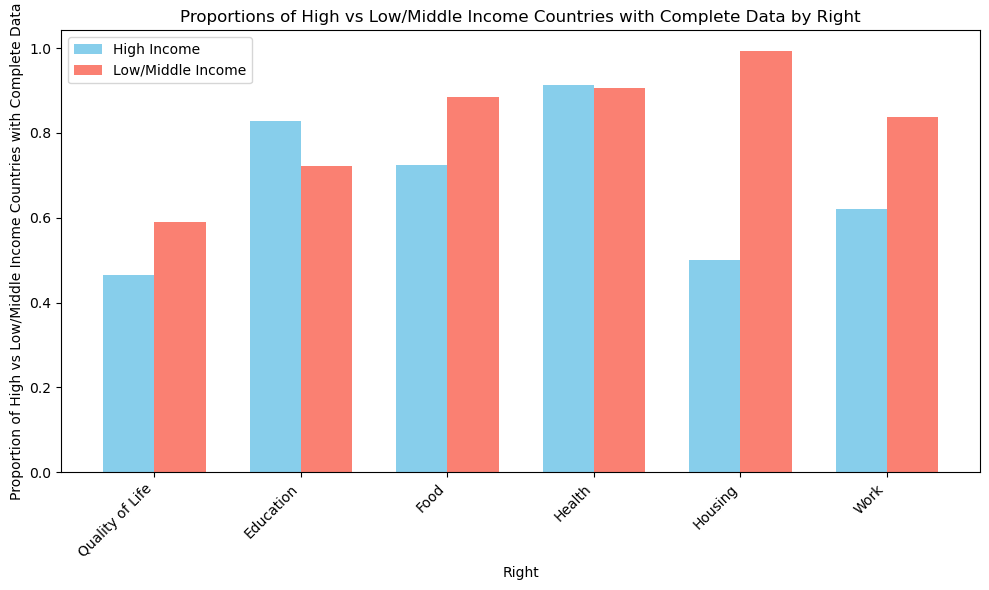

```python
# Same visualization but with PROPORTIONS
# Number of categories
x = np.arange(len(country_counts_rights['Right']))  # x positions for the categories
width = 0.35  # Bar width for each group

# Plotting the two-bar grouped bar plot
fig, ax = plt.subplots(figsize=(10, 6))

# Create bars for both groups
bars1 = ax.bar(x - width/2, country_counts_rights['HiY Prop_Countries_Complete'], width, label='High Income', color='skyblue')
bars2 = ax.bar(x + width/2, country_counts_rights['LMY Prop_Countries_Complete'], width, label='Low/Middle Income', color='salmon')

# Labels and title
ax.set_xlabel('Right')
ax.set_ylabel('Proportion of High vs Low/Middle Income Countries with Complete Data')
ax.set_title('Proportions of High vs Low/Middle Income Countries with Complete Data by Right')

# Set x-ticks and labels
ax.set_xticks(x)
ax.set_xticklabels(country_counts_rights['Right'], rotation=45, ha='right')

# Add a legend
ax.legend()

# Layout adjustment
plt.tight_layout()

# Show the plot
plt.show()
```

#### From the above data analysis, we decided to focus on the health and education rights, because these had the highest number of valid high income countries (and there were much less valid high income countries than low/middle income)

# Insight 1: Comparing Right to Health by Income and Region

Insight Summary: Higher-income regions consistently score better on the right to health, exposing a stark divide in health equity that disadvantages low- and middle-income countries.

## Historical Health Score Trends Across Income Levels

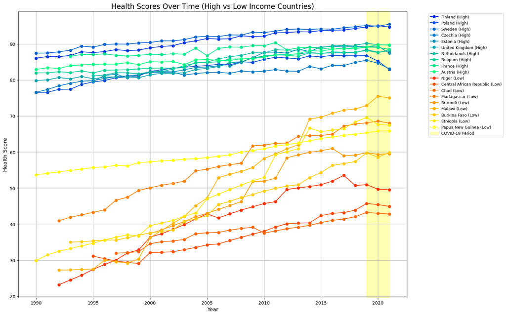

```python
import matplotlib.pyplot as plt
import pandas as pd
import matplotlib.cm as cm
import numpy as np

# Create country groups
top_high_income_countries = [
    'Finland', 'Poland', 'Sweden', 'Czechia', 'Estonia',
    'United Kingdom', 'Netherlands', 'Belgium', 'France', 'Austria'
]

bottom_income_countries = [
    'Niger', 'Central African Republic', 'Chad', 'Madagascar', 'Burundi',
    'Malawi', 'Burkina Faso', 'Ethiopia', 'Papua New Guinea'
]

# Extract relevant health data
high_income_health = esr_hiy_globalbest[
    esr_hiy_globalbest['Country'].isin(top_high_income_countries)
][['Country', 'Year', 'HiY_Health_All_GBScore', 'SeniorSurvival_All_MRValue']]

low_income_health = esr_lmy_globalbest[
    esr_lmy_globalbest['Country'].isin(bottom_income_countries)
][['Country', 'Year', 'LMY_Health_All_GBScore', 'AdultSurvival_All_MRValue']]

# Plotting in a single figure
fig, ax = plt.subplots(figsize=(16, 10))

# Cool tones for high-income countries
cool_colors = cm.winter(np.linspace(0.2, 1, len(top_high_income_countries)))

for i, country in enumerate(top_high_income_countries):
    data = high_income_health[high_income_health['Country'] == country]
    ax.plot(data['Year'], data['HiY_Health_All_GBScore'],
            label=f"{country} (High)", color=cool_colors[i], marker='o')

# Cool tones for low-income countries
warm_colors = cm.autumn(np.linspace(0.2, 1, len(bottom_income_countries)))

for i, country in enumerate(bottom_income_countries):
    data = low_income_health[low_income_health['Country'] == country]
    ax.plot(data['Year'], data['LMY_Health_All_GBScore'],
            label=f"{country} (Low)", color=warm_colors[i], marker='o')

#highlight covid years
plt.axvspan(2019, 2021, color='yellow', alpha=0.3, label='COVID-19 Period')

# Plot styling
ax.set_title('Health Scores Over Time (High vs Low Income Countries)', fontsize=16)
ax.set_xlabel('Year', fontsize=12)
ax.set_ylabel('Health Score', fontsize=12)
ax.grid(True)
ax.legend(bbox_to_anchor=(1.05, 1), loc='upper left', fontsize=9)
plt.tight_layout()
plt.show()
```

1. Overview

2. Key Visual Insights

High-income countries exhibit consistently high health scores with minimal year-over-year (YoY) change.

Low-income countries show more volatile patterns with intermittent positive trends, suggesting recent improvements.

3. Notable Insights from YoY Changes

Burkina Faso and Ethiopia show visible upward momentum in health scores, with occasional sharp increases not mirrored in high-income countries.

High-income countries (e.g., Finland, Austria) remain near a health performance ceiling, with plateau effects becoming apparent.

4. Summary Statistics Reveal

Low-income group: Increasing mean in recent years with persistent high variance => emerging but uneven progress.

5. Insightful Patterns

Despite a persistent gap, some low-income nations are closing the distance incrementally.

Temporal clustering of growth in certain years (e.g., around 2015) may reflect coordinated global health initiatives or aid programs.

6. Conclusion

While high-income countries maintain top-tier health scores, the real story lies in the growth patterns of certain low-income nations. These shifts offer a hopeful view into the potential impact of sustained health investments.

### COVID-19 Impact Statistics (2019 to 2020+)

```python
# COVID impact statistics
def calculate_covid_impact(df, country, score_column):
    country_data = df[df['Country'] == country]
    pre_covid = country_data[country_data['Year'] == 2019][score_column].mean()
    during_covid = country_data[country_data['Year'] >= 2020][score_column].mean()
    change = during_covid - pre_covid
    return {'country': country, 'pre_covid': pre_covid, 'during_covid': during_covid, 'change': change}

# Impact for all countries
high_income_impacts = [calculate_covid_impact(high_income_health, country, 'HiY_Health_All_GBScore')
                      for country in top_high_income_countries]
low_income_impacts = [calculate_covid_impact(low_income_health, country, 'LMY_Health_All_GBScore')
                     for country in bottom_income_countries]

# Visualization
high_income_impacts_df = pd.DataFrame(high_income_impacts)
low_income_impacts_df = pd.DataFrame(low_income_impacts)

print("\nCOVID Impact Analysis for High-Income Countries:")
print(high_income_impacts_df.sort_values('change', ascending=False))

print("\nCOVID Impact Analysis for Low-Income Countries:")
print(low_income_impacts_df.sort_values('change', ascending=False))

# Average impacts
print("\nAverage Changes:")
print(f"High-Income Countries: {high_income_impacts_df['change'].mean():.2f}")
print(f"Low-Income Countries: {low_income_impacts_df['change'].mean():.2f}")
```

```
COVID Impact Analysis for High-Income Countries:
          country  pre_covid  during_covid    change
9         Austria  89.162318     89.700452  0.538134
0         Finland  94.682446     94.835962  0.153516
2          Sweden  95.105184     95.158645  0.053461
7         Belgium  88.137763     87.975584 -0.162179
8          France  89.085131     88.740751 -0.344380
6     Netherlands  90.137887     89.681296 -0.456590
5  United Kingdom  88.366886     87.866707 -0.500179
4         Estonia  89.198902     88.397467 -0.801435
3         Czechia  85.440483     83.836411 -1.604071
1          Poland  86.725823     84.032875 -2.692949

COVID Impact Analysis for Low-Income Countries:
                    country  pre_covid  during_covid    change
5                    Malawi  72.879185     75.233991  2.354806
8          Papua New Guinea  65.331076     65.818155  0.487079
3                Madagascar  68.084497     68.274888  0.190391
4                   Burundi  59.770647     59.423445 -0.347202
2                      Chad  43.230563     42.875867 -0.354697
6              Burkina Faso  59.750836     59.197086 -0.553750
1  Central African Republic  45.702872     45.147783 -0.555089
0                     Niger  50.930900     49.587247 -1.343653
7                  Ethiopia  69.568900     67.520301 -2.048599

Average Changes:
High-Income Countries: -0.58
Low-Income Countries: -0.24
```

#### High-Income Countries (e.g., Finland, Poland, UK):

- `Avg. Change: −0.58`

Mixed results: Austria & Finland improved slightly, while Poland saw the largest drop (−2.69).

#### Low-Income Countries (e.g., Niger, Ethiopia, Malawi):

- `Avg. Change: −0.24`

Malawi improved the most (+2.35), while Ethiopia declined significantly (−2.05).

#### Summary

Surprisingly, high-income countries experienced a larger average decline in health scores during COVID than low-income ones, possibly due to higher baselines, aging populations, or overwhelmed systems.

So, economic status alone does not determine resilience in health metrics. System adaptability and contextual factors matter more in crisis response.

### Graph: Year-over-year change in health scores for random high- and low/middle-income countries

```
Random 10 high income countries:
Country
Germany            75.929806
Latvia             75.746258
Greece             65.063434
Slovak Republic    75.098126
Austria            79.885596
Ireland            76.115700
Netherlands        79.975679
Norway             78.057857
Italy              72.398080
Sweden             82.938374
Name: HiY_QofL_All_GBScore, dtype: float64

Random 10 low income countries:
Country
Kazakhstan    84.764106
Ecuador       79.631133
Montenegro    83.659120
Serbia        85.157882
Albania       79.886509
Ethiopia      41.860375
Jordan        84.992262
Peru          78.258196
Bulgaria      84.198861
Lesotho       47.820739
Name: LMY_QofL_All_GBScore, dtype: float64
Random High-Income Countries: ['Germany', 'Latvia', 'Greece', 'Slovak Republic', 'Austria', 'Ireland', 'Netherlands', 'Norway', 'Italy', 'Sweden']
Random Low-Income Countries: ['Kazakhstan', 'Ecuador', 'Montenegro', 'Serbia', 'Albania', 'Ethiopia', 'Jordan', 'Peru', 'Bulgaria', 'Lesotho']
```

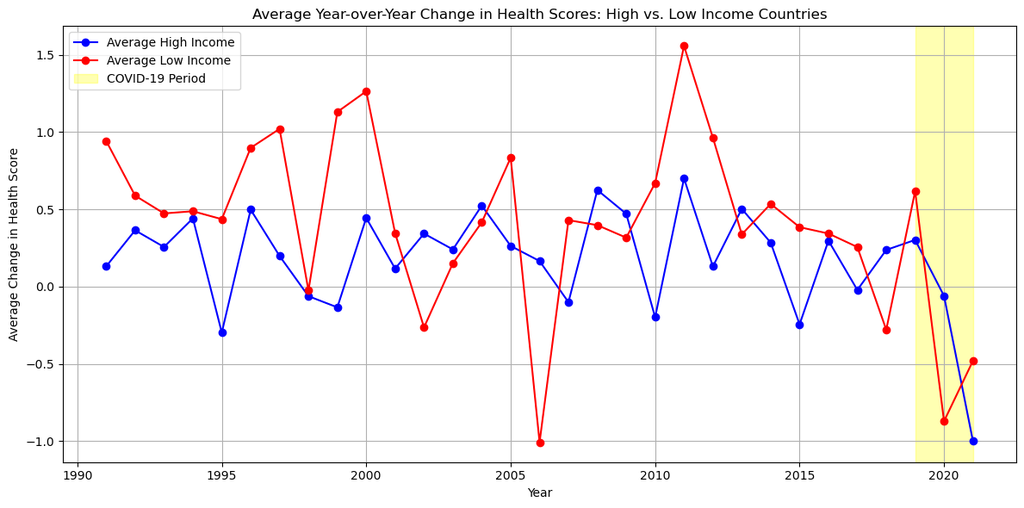

```python
 #For Random High-Income Countries
 # Select 10 random high-income countries (instead of top 10)
random_high_income = (
    esr_hiy_globalbest[esr_hiy_globalbest['High_Income_Country'] == 1]
    .groupby('Country')['HiY_QofL_All_GBScore']
    .mean()
    .dropna()
    .sample(10, random_state=42)  # random_state ensures reproducibility
)
print("Random 10 high income countries: ")
print(random_high_income)
#For Random Low-Income Countries (Bottom-Income Group)
# Select 10 random low/middle-income countries (instead of bottom 10)
random_low_income = (
    esr_lmy_globalbest[esr_lmy_globalbest['High_Income_Country'] == 0]
    .groupby('Country')['LMY_QofL_All_GBScore']
    .mean()
    .dropna()
    .sample(10, random_state=42)  # random_state ensures reproducibility
)
print("\nRandom 10 low income countries: ")
print(random_low_income)



high_income_countries = random_high_income.index.tolist()
print("Random High-Income Countries:", high_income_countries)
low_income_countries = random_low_income.index.tolist()
print("Random Low-Income Countries:", low_income_countries)


# Extract relevant health data
high_income_health = esr_hiy_globalbest[
    esr_hiy_globalbest['Country'].isin(high_income_countries)
][['Country', 'Year', 'HiY_Health_All_GBScore', 'SeniorSurvival_All_MRValue']]

low_income_health = esr_lmy_globalbest[
    esr_lmy_globalbest['Country'].isin(low_income_countries)
][['Country', 'Year', 'LMY_Health_All_GBScore', 'AdultSurvival_All_MRValue']]

# 2. From Lecture 18 (Panel Data), calculated:
# - Year-over-year changes
# - Growth rates
# - Rolling averages

# For high-income countries
high_income_panel = high_income_health.sort_values(['Country', 'Year'])
high_income_panel['YoY_Change'] = high_income_panel.groupby('Country')['HiY_Health_All_GBScore'].diff()
high_income_panel['Growth_Rate'] = high_income_panel.groupby('Country')['HiY_Health_All_GBScore'].pct_change()

# For low-income countries
low_income_panel = low_income_health.sort_values(['Country', 'Year'])
low_income_panel['YoY_Change'] = low_income_panel.groupby('Country')['LMY_Health_All_GBScore'].diff()
low_income_panel['Growth_Rate'] = low_income_panel.groupby('Country')['LMY_Health_All_GBScore'].pct_change()

# Plot both on the same graph
avg_high_income = high_income_panel.groupby('Year')['YoY_Change'].mean().reset_index()
avg_low_income = low_income_panel.groupby('Year')['YoY_Change'].mean().reset_index()

plt.figure(figsize=(12, 6))
plt.plot(avg_high_income['Year'], avg_high_income['YoY_Change'], marker='o', color='blue', label='Average High Income')
plt.plot(avg_low_income['Year'], avg_low_income['YoY_Change'], marker='o', color='red', label='Average Low Income')

#highlight covid years
plt.axvspan(2019, 2021, color='yellow', alpha=0.3, label='COVID-19 Period')

plt.title('Average Year-over-Year Change in Health Scores: High vs. Low Income Countries')
plt.xlabel('Year')
plt.ylabel('Average Change in Health Score')
plt.legend(loc='best')
plt.grid(True)
plt.tight_layout()
plt.show()
```

This figure shows the average year-over-year changes in health scores for **10 random** high-income and **10 random** low/middle-income countries from 1990 to 2021. Each dot for each year represents that year's average health score subtracted by the previous year's average health score. High-income countries are represented by a blue line, whereas low-income countries are represented by a red line. The period shaded in yellow represents the period of time we focused on to analyze COVID-19 effects (2019-2021).

Low-income countries (red line) generally experienced more volatility—but also more frequent spikes—in year-over-year health score improvements compared to high-income countries (blue line), which saw steadier but more modest gains. However, both groups saw sharp declines around 2020–2021, likely reflecting the global impact of COVID-19.

## Health Score Trends By Region

### Preparing the data for visualization

```python
# filter datasets to only include high income and hrmi_lo to only include low income
hrmi_hi = esr_hiy_globalbest[esr_hiy_globalbest['High_Income_Country'] == 1]
hrmi_lo = esr_lmy_globalbest[esr_lmy_globalbest['High_Income_Country'] == 0]

# Combine HRMI
hi = hrmi_hi[['Country', 'Year', 'HiY_Health_All_GBScore']].rename(columns={'HiY_Health_All_GBScore': 'Health_GBScore'})
lo = hrmi_lo[['Country', 'Year', 'LMY_Health_All_GBScore']].rename(columns={'LMY_Health_All_GBScore': 'Health_GBScore'})
hrmi_combined = pd.concat([hi, lo], ignore_index=True)

# Name mapping
name_mapping = {
    'United States': 'United States of America',
    'United Kingdom': 'United Kingdom',
    'Iran, Islamic Rep.': 'Iran (Islamic Republic of)',
    'Korea, Rep.': 'Republic of Korea',
    'Egypt, Arab Rep.': 'Egypt',
    'Russia': 'Russian Federation',
    'Turkey': 'Türkiye'
}
hrmi_combined['Country'] = hrmi_combined['Country'].replace(name_mapping)
```

```python
# categorize by region based on HRMI Rights Tracker website country filter
# split "americas" into northern, middle, and south bc of cultural differences
northern_america = ['United States of America', 'Canada']

middle_america = [
    'Mexico', 'Belize', 'Guatemala', 'Honduras', 'El Salvador', 'Nicaragua',
    'Costa Rica', 'Panama', 'Jamaica', 'Barbados', 'Dominican Republic',
    'St. Lucia', 'Trinidad and Tobago', 'Haiti', 'Bahamas, The',
    'Antigua and Barbuda'
]

south_america = [
    'Argentina', 'Bolivia', 'Brazil', 'Chile', 'Colombia', 'Ecuador',
    'Guyana', 'Paraguay', 'Peru', 'Suriname', 'Uruguay'
]

middle_east = [
    'Iran (Islamic Republic of)', 'Lebanon', 'West Bank and Gaza', 'Jordan', 'Iraq',
    'Qatar', 'Oman', 'Saudi Arabia', 'United Arab Emirates',
    'Bahrain', 'Israel', 'Kuwait'
]

north_africa = ['Morocco', 'Egypt', 'Tunisia', 'Algeria', 'Libya']

sub_saharan_africa = [
    'Cabo Verde', 'Sao Tome and Principe', 'Zimbabwe', 'Malawi', 'Rwanda',
    'South Africa', 'Mauritius', 'Kenya', 'Eswatini', 'Namibia',
    'Ethiopia', 'Zambia', 'Madagascar', 'Senegal', 'Tanzania',
    'Lesotho', 'Uganda', 'Ghana', 'Mauritania', 'Gabon',
    'Burundi', 'Burkina Faso', 'Gambia, The', 'Comoros', 'Mozambique',
    'Sudan', 'Togo', 'Congo, Rep.', 'Guinea-Bissau', 'Liberia',
    'Congo, Dem. Rep.', 'Sierra Leone', 'Cameroon', 'Angola', 'Mali',
    'Benin', "Cote d'Ivoire", 'Niger', 'Guinea', 'Equatorial Guinea',
    'Central African Republic', 'Nigeria', 'Somalia', 'Chad',
    'Seychelles', 'Botswana'
]

europe = [
    'Finland', 'Germany', 'France', 'United Kingdom', 'Ireland',
    'Switzerland', 'Belgium', 'Spain', 'Austria', 'Estonia', 'Italy',
    'Hungary', 'Poland', 'Russian Federation', 'Lithuania', 'Ukraine', 'Belarus',
    'Moldova', 'Armenia', 'Georgia', 'Serbia', 'North Macedonia',
    'Bosnia and Herzegovina', 'Montenegro', 'Albania', 'Czechia',
    'Denmark', 'Greece', 'Croatia', 'Iceland', 'Luxembourg', 'Latvia',
    'Malta', 'Netherlands', 'Norway', 'Portugal', 'Romania', 'San Marino',
    'Slovak Republic', 'Slovenia', 'Sweden', 'Bulgaria'
]

central_asia = [
    'Turkiye', 'Kazakhstan', 'Kyrgyz Republic', 'Turkmenistan', 'Tajikistan', 'Azerbaijan', 'Uzbekistan'
]

south_asia = [
    'Bhutan', 'Sri Lanka', 'Bangladesh', 'India',
    'Nepal', 'Maldives', 'Pakistan', 'Afghanistan'
]

east_asia = [
    'China', 'Thailand', 'Viet Nam', 'Taiwan', 'Indonesia',
    'Mongolia', 'Lao PDR', 'Philippines', 'Japan', 'Myanmar',
    'Malaysia', 'Cambodia', 'Timor-Leste', 'Brunei Darussalam',
    'Republic of Korea', 'Singapore'
]

pacific = [
    'Australia', 'Micronesia (Federated States)', 'Vanuatu',
    'Fiji', 'Marshall Islands', 'Tonga', 'Solomon Islands',
    'Samoa', 'Papua New Guinea', 'Palau', 'Kiribati',
    'Nauru', 'Tuvalu', 'New Zealand', 'Micronesia, Fed. Sts.'
]

country_to_region = {
    **{c: 'Northern America' for c in northern_america},
    **{c: 'Middle America' for c in middle_america},
    **{c: 'South America' for c in south_america},
    **{c: 'Middle East' for c in middle_east},
    **{c: 'North Africa' for c in north_africa},
    **{c: 'Sub-Saharan Africa' for c in sub_saharan_africa},
    **{c: 'Europe' for c in europe},
    **{c: 'Central Asia' for c in central_asia},
    **{c: 'South Asia' for c in south_asia},
    **{c: 'East Asia' for c in east_asia},
    **{c: 'Pacific' for c in pacific}
}

# regions for the hrmi_combined df
hrmi_combined['Region'] = hrmi_combined['Country'].map(country_to_region)
```

### Graph: Average health score by region over time

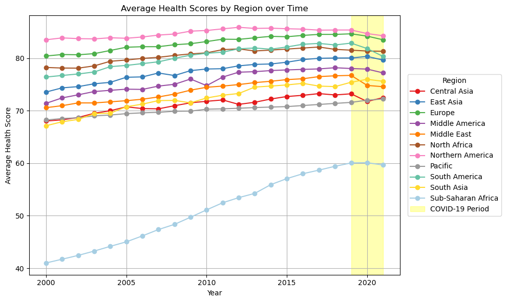

```python
# change time range to 2000-2021, in order to have historical data + enough valid countries w/out missing data
hrmi_combined = hrmi_combined[(hrmi_combined['Year'] >= 2000) & (hrmi_combined['Year'] <= 2021)]
# remove any countries that have missing health score data for 2000-2021
hrmi_combined = hrmi_combined.groupby('Country').filter(lambda x: x['Health_GBScore'].notna().all())
# graph of each region's avg health score during 2000-2021
avg_health_scores = hrmi_combined.groupby(['Region', 'Year'])['Health_GBScore'].mean().reset_index()

colors = [
    '#E41A1C',  # red
    '#377EB8',  # blue
    '#4DAF4A',  # green
    '#984EA3',  # purple
    '#FF7F00',  # orange
    '#A65628',  # brown
    '#F781BF',  # pink
    '#999999',  # gray
    '#66C2A5',  # turquoise
    '#FFD92F',  # yellow
    '#A6CEE3'   # light blue
]

plt.figure(figsize=(10, 6))
for i, region in enumerate(avg_health_scores['Region'].unique()):
    region_data = avg_health_scores[avg_health_scores['Region'] == region]
    plt.plot(region_data['Year'], region_data['Health_GBScore'], marker='o', label=region, color=colors[i])

#highlight covid years
plt.axvspan(2019, 2021, color='yellow', alpha=0.3, label='COVID-19 Period')

plt.title('Average Health Scores by Region over Time')
plt.xlabel('Year')
plt.ylabel('Average Health Score')
plt.legend(
    title='Region',
    loc='center left',
    bbox_to_anchor=(1.02, 0.5),
    borderaxespad=0
)
plt.grid(True)
plt.tight_layout()
plt.show()
```

This figure shows the average health scores for each world region from 2000-2021. The period shaded in yellow represents the period of time we focused on to analyze COVID-19 effects (2019-2021).

### Graph: Year-over-year change in health scores by region

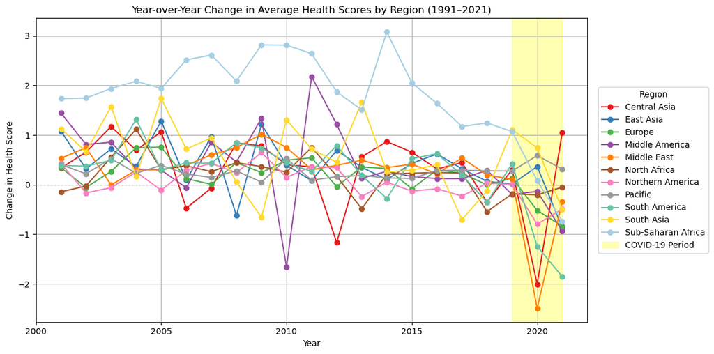

```python
# year over year change in health scores
avg_health_scores = avg_health_scores.sort_values(['Region', 'Year'])
avg_health_scores['YoY_Pct_Change'] = avg_health_scores.groupby('Region')['Health_GBScore'].pct_change() * 100

plt.figure(figsize=(12, 6))
for i, region in enumerate(avg_health_scores['Region'].unique()):
    region_data = avg_health_scores[avg_health_scores['Region'] == region]
    plt.plot(region_data['Year'], region_data['YoY_Pct_Change'], marker='o', label=region, color=colors[i])

#highlight covid years
plt.axvspan(2019, 2021, color='yellow', alpha=0.3, label='COVID-19 Period')

plt.title('Year-over-Year Change in Average Health Scores by Region (1991–2021)')
plt.xlabel('Year')
plt.ylabel('Change in Health Score')
plt.axhline(0, color='gray', linestyle='--', linewidth=0.8)
plt.legend(
    title='Region',
    loc='center left',
    bbox_to_anchor=(1.02, 0.5),
    borderaxespad=0
)
plt.grid(True)

# years by 5
plt.xticks(np.arange(2000, 2022, 5))

plt.tight_layout()
plt.show()
```

#### Summary

This analysis provides more insight into the health score trends found among high and low/middle income countries. We hypothesized that culture, geography, and the broader political climate may play a role in overall health scores as well as COVID-19 response, and we decided to explore this by visualizing the average health scores and year-over-year changes by world region. We used data from 2000 till 2021 to investigate health scores both over an extended period of time, as well as during COVID-19. In order to preserve the accuracy of the aggregated calculations, these graphs only utilize data from countries that have reported health scores from all years between 2000 and 2021 (inclusive).

We used the regions and subregions found on the HRMI Rights Tracker website filter, with the exception of splitting "Americas" into "Northern America", "Middle America", and "South America" because of cultural/geographical/political differences in those regions.

Key Insights from Average Health Scores

1. Sub-Saharan Africa was a consistently low outlier, scoring more than 10 points below the second-lowest-scoring region from 2020 to 2021. However, it also showed the most improvement throughout this time period, with a 20pt increase from 2000 to 2021.
2. The rest of the regions showed gradual improvement over time, but collectively, their health scores stayed within the 65-85 range. Northern America consistently had the highest health scores, while the Pacific region was at the bottom of the pack for the majority of this time frame. South Asia entered the 21st century with health scores lower than the Pacific, but they experienced significant improvement throughout the next two decades.

Key Insights from Change in Health Scores

1. For the most part, sharp positive and negative changes in health scores during specific years are not shared across regions, confirming that each region indeed undergoes unique challenges and successes in regards to health.
2. The exception to this was the year 2020, during which the majority of regions experienced a significant drop in health scores, likely due to COVID-19. Interestingly, South Asia, the Pacific, East Asia, and Sub-Saharan Africa experienced a positive change in health scores between 2019 and 2020. One piece of information that we do not have is the exact point in the year during which these data were collected. This would help us theorize why this positive change occurred, as COVID-19 spread to different world regions at different times. For example, perhaps East Asia may have recovered earlier than other regions due to it being the pandemic's region of origin.
3. Central Asia and the Pacific experienced a positive change in health scores between 2020 and 2021, whereas every other region experienced a decrease in health scores. Like the previous point, this could also be due to the timeline of data collection and measures utilized.

**Key Takeaway:** Taken together with the income comparison data, these graphs suggest that there may be complex, region-specific factors that affect a country's ability to provide for their citizens in the realm of health, especially in response to a global crisis such as COVID-19.

# Insight 2: Comparing COVID-19 Death Rates by Right to Health Score

Insight Summary: Countries with similar health rights scores experienced vastly different COVID-19 death rates, suggesting that swift and effective policy responses mattered more than pre-existing health infrastructure alone.

## Explore external WHO dataset alongside ESR

```python
import pandas as pd

# Load the dataset
df = pd.read_csv("csv files/WHO-COVID-19-global-data.csv")
```

```python
# Convert date column to datetime format
df['Date_reported'] = pd.to_datetime(df['Date_reported'])

# Extract year from date
df['Year'] = df['Date_reported'].dt.year

# Drop rows with missing country or year data
df = df.dropna(subset=['Country', 'Year'])

# Fill missing new cases/deaths with 0
df['New_cases'] = df['New_cases'].fillna(0)
df['New_deaths'] = df['New_deaths'].fillna(0)

# Group by Country and Year, summing new cases and deaths
agg_df = df.groupby(['Country', 'Year'])[['New_cases', 'New_deaths']].sum().reset_index()

# Save to new CSV
agg_df.to_csv("WHO_Aggregated_By_Country_Year.csv", index=False)

print("Aggregation complete. File saved as 'WHO_Aggregated_By_Country_Year.csv'")
```

```
Aggregation complete. File saved as 'WHO_Aggregated_By_Country_Year.csv'
```

```python
#clean data

df['New_deaths'] = df['New_deaths'].fillna(0)

# Group by country and sum total deaths
country_deaths = df.groupby('Country')['New_deaths'].sum().reset_index()

# Calculate the average deaths per country
average_deaths = country_deaths['New_deaths'].mean()

print(f"Average number of deaths per country: {average_deaths:,.0f}")
```

```
Average number of deaths per country: 29,555
```

```python
# Group by country and sum total deaths
country_deaths = df.groupby('Country')['New_deaths'].sum().reset_index()

# Sort from highest to lowest deaths
country_deaths = country_deaths.sort_values(by='New_deaths', ascending=False)

# Print top 10 countries
print("Total COVID-19 deaths per country:\n")
print(country_deaths.to_string(index=False))
```

```
Total COVID-19 deaths per country:

                                                               Country  New_deaths
                                              United States of America   1221449.0
                                                                Brazil    702689.0
                                                                 India    533662.0
                                                    Russian Federation    404290.0
                                                                Mexico    334818.0
                  United Kingdom of Great Britain and Northern Ireland    232112.0
                                                                  Peru    220994.0
                                                                 Italy    198386.0
                                                               Germany    174979.0
                                                                France    168162.0
                                                             Indonesia    162059.0
                                            Iran (Islamic Republic of)    146837.0
                                                              Colombia    142748.0
                                                             Argentina    130747.0
                                                                 China    122398.0
                                                                 Spain    121852.0
                                                                Poland    121016.0
                                                               Ukraine    109925.0
                                                          South Africa    102595.0
                                                               T�rkiye    101419.0
                                                                 Japan     74694.0
                                                               Romania     68963.0
                                                           Philippines     66864.0
                                                                 Chile     62871.0
                                                                Canada     55282.0
                                                               Hungary     49124.0
                                                               Czechia     43808.0
                                                              Viet Nam     43206.0
                                                                Greece     40056.0
                                                              Bulgaria     38765.0
                                                              Malaysia     37351.0
                                                               Ecuador     36056.0
                                                     Republic of Korea     35934.0
                                                              Thailand     34744.0
                                                               Belgium     34339.0
                                                              Pakistan     30656.0
                                                            Bangladesh     29499.0
```

[output cut: 188 more lines]

```
                                                                Tuvalu         1.0
                                                                 Nauru         1.0
                                                               Tokelau         0.0
                                    International conveyance (Vanuatu)         0.0
                                                          Saint Helena         0.0
                                       International commercial vessel         0.0
                                           Falkland Islands (Malvinas)         0.0
                                                              Pitcairn         0.0
                             International conveyance (American Samoa)         0.0
                                 Democratic People's Republic of Korea         0.0
                            International conveyance (Solomon Islands)         0.0
                                                                  Niue         0.0
                                                              Holy See         0.0
                                   International conveyance (Kiribati)         0.0
                                                          Turkmenistan         0.0
```

#### Now we want to see which usuable countries overlap from our WHO data set and the class data set

```python
#  Define HRMI Valid Countries (from cleaned dataset outputs)
# Includes high-income + low-income countries that passed filtering

hrmi_valid_countries = {
    'Antigua and Barbuda', 'Australia', 'Austria', 'Bahamas, The', 'Bahrain', 'Barbados', 'Belgium',
    'Brunei Darussalam', 'Canada', 'Chile', 'Croatia', 'Cyprus', 'Czechia', 'Denmark', 'Estonia',
    'Finland', 'France', 'Germany', 'Greece', 'Hong Kong SAR, China', 'Hungary', 'Iceland', 'Ireland',
    'Israel', 'Italy', 'Japan', 'Korea, Rep.', 'Kuwait', 'Latvia', 'Lithuania', 'Luxembourg',
    'Macao SAR, China', 'Malta', 'Nauru', 'Netherlands', 'New Zealand', 'Norway', 'Oman', 'Panama',
    'Poland', 'Portugal', 'Qatar', 'Romania', 'San Marino', 'Seychelles', 'Singapore',
    'Slovak Republic', 'Slovenia', 'Spain', 'St. Kitts and Nevis', 'Sweden', 'Switzerland', 'Taiwan',
    'Trinidad and Tobago', 'United Arab Emirates', 'United Kingdom', 'United States', 'Uruguay',
    'Afghanistan', 'Albania', 'Algeria', 'Angola', 'Argentina', 'Armenia', 'Azerbaijan', 'Bangladesh',
    'Belarus', 'Belize', 'Benin', 'Bhutan', 'Bolivia', 'Bosnia and Herzegovina', 'Botswana', 'Brazil',
    'Bulgaria', 'Burkina Faso', 'Burundi', 'Cabo Verde', 'Cambodia', 'Cameroon',
    'Central African Republic', 'Chad', 'China', 'Colombia', 'Comoros', 'Congo, Dem. Rep.',
    'Congo, Rep.', 'Costa Rica', "Cote d'Ivoire", 'Djibouti', 'Dominica', 'Dominican Republic',
    'Ecuador', 'Egypt, Arab Rep.', 'El Salvador', 'Equatorial Guinea', 'Eswatini', 'Ethiopia', 'Fiji',
    'Gabon', 'Gambia', 'Georgia', 'Ghana', 'Grenada', 'Guatemala', 'Guinea', 'Guinea–Bissau', 'Guyana',
    'Haiti', 'Honduras', 'India', 'Indonesia', 'Iran, Islamic Rep.', 'Iraq', 'Jamaica', 'Jordan',
    'Kazakhstan', 'Kenya', 'Kiribati', 'Kosovo', 'Kyrgyz Republic', 'Lao PDR', 'Lebanon', 'Lesotho',
    'Liberia', 'Libya', 'Madagascar', 'Malawi', 'Malaysia', 'Maldives', 'Mali', 'Marshall Islands',
    'Mauritania', 'Mauritius', 'Mexico', 'Micronesia, Fed. Sts.', 'Moldova', 'Mongolia', 'Montenegro',
    'Morocco', 'Mozambique', 'Myanmar', 'Namibia', 'Nepal', 'Nicaragua', 'Niger', 'Nigeria',
    'North Macedonia', 'Pakistan', 'Palau', 'Papua New Guinea', 'Paraguay', 'Peru', 'Philippines',
    'Russian Federation', 'Rwanda', 'Samoa', 'Sao Tome and Principe', 'Senegal', 'Serbia',
    'Sierra Leone', 'Solomon Islands', 'Somalia', 'South Africa', 'Sri Lanka', 'St. Lucia',
    'St. Vincent and the Grenadines', 'Sudan', 'Suriname', 'Tajikistan', 'Tanzania', 'Thailand',
    'Timor-Leste', 'Togo', 'Tonga', 'Tunisia', 'Turkiye', 'Turkmenistan', 'Tuvalu', 'Uganda',
    'Ukraine', 'Uzbekistan', 'Vanuatu', 'Viet Nam', 'West Bank and Gaza', 'Zambia', 'Zimbabwe'
}

#  WHO Countries
who_countries = {
    'Afghanistan', 'Albania', 'Algeria', 'Argentina', 'Australia', 'Austria', 'Bangladesh', 'Belgium',
    'Brazil', 'Canada', 'Chile', 'China', 'Colombia', 'Czechia', 'Denmark', 'Dominican Republic',
    'Ecuador', 'Egypt', 'Ethiopia', 'Finland', 'France', 'Germany', 'Greece', 'Hungary', 'India',
    'Indonesia', 'Iran (Islamic Republic of)', 'Iraq', 'Ireland', 'Israel', 'Italy', 'Japan', 'Jordan',
    'Kenya', 'Malaysia', 'Mexico', 'Morocco', 'New Zealand', 'Nigeria', 'Norway', 'Pakistan', 'Peru',
    'Philippines', 'Poland', 'Portugal', 'Republic of Korea', 'Romania', 'Russian Federation',
    'Saudi Arabia', 'South Africa', 'Spain', 'Sri Lanka', 'Sweden', 'Switzerland', 'Thailand',
    'Tunisia', 'Türkiye', 'Ukraine', 'United Arab Emirates', 'United Kingdom',
    'United States of America', 'Viet Nam', 'Zambia', 'Zimbabwe'
}

# Name harmonization — map HRMI names to WHO equivalents
name_mapping = {
    'United States': 'United States of America',
    'United Kingdom': 'United Kingdom',
    'Iran, Islamic Rep.': 'Iran (Islamic Republic of)',
    'Korea, Rep.': 'Republic of Korea',
    'Turkiye': 'Türkiye',
    'Viet Nam': 'Viet Nam',
    'Egypt, Arab Rep.': 'Egypt'
}

# Apply name changes to HRMI dataset to understand what countries we can use
hrmi_mapped = {name_mapping.get(c, c) for c in hrmi_valid_countries}

# Identify intersections
overlap_and_valid = sorted(hrmi_mapped.intersection(who_countries))          #Correct ones
overlap_but_invalid = sorted(who_countries.difference(hrmi_mapped))          # WHO data but not HRMI valid
```

Overlapping countries

```python
#  HRMI Valid + WHO Overlapping Countries (from earlier filtering steps)
overlapping_countries = [
    'Afghanistan', 'Albania', 'Algeria', 'Argentina', 'Australia', 'Austria', 'Bangladesh', 'Belgium',
    'Brazil', 'Canada', 'Chile', 'China', 'Colombia', 'Czechia', 'Denmark', 'Dominican Republic',
    'Ecuador', 'Egypt', 'Ethiopia', 'Finland', 'France', 'Germany', 'Greece', 'Hungary', 'India',
    'Indonesia', 'Iran (Islamic Republic of)', 'Iraq', 'Ireland', 'Israel', 'Italy', 'Japan', 'Jordan',
    'Kenya', 'Malaysia', 'Mexico', 'Morocco', 'New Zealand', 'Nigeria', 'Norway', 'Pakistan', 'Peru',
    'Philippines', 'Poland', 'Portugal', 'Republic of Korea', 'Romania', 'Russian Federation',
    'South Africa', 'Spain', 'Sri Lanka', 'Sweden', 'Switzerland', 'Thailand', 'Tunisia', 'Türkiye',
    'Ukraine', 'United Arab Emirates', 'United Kingdom', 'United States of America', 'Viet Nam',
    'Zambia', 'Zimbabwe'
]

# World Bank-style High-Income Countries (can be modified if needed)
high_income_countries = {
    'Australia', 'Austria', 'Belgium', 'Canada', 'Chile', 'Czechia', 'Denmark', 'Finland', 'France',
    'Germany', 'Greece', 'Ireland', 'Israel', 'Italy', 'Japan', 'Republic of Korea', 'New Zealand',
    'Norway', 'Poland', 'Portugal', 'Spain', 'Sweden', 'Switzerland', 'United Arab Emirates',
    'United Kingdom', 'United States of America'
}

# Split into income groups
high_income_overlap = sorted([c for c in overlapping_countries if c in high_income_countries])
low_middle_income_overlap = sorted([c for c in overlapping_countries if c not in high_income_countries])

#  OUTPUT for your team
print(" Total Countries with Valid Data in Both WHO & HRMI:", len(overlapping_countries))
print("-------------------------------------------------------")
print(overlapping_countries)

print("\n High-Income Countries ({}):".format(len(high_income_overlap)))
print("-------------------------------------------------------")
print(high_income_overlap)

print("\n Low- and Middle-Income Countries ({}):".format(len(low_middle_income_overlap)))
print("-------------------------------------------------------")
print(low_middle_income_overlap)
```

```
 Total Countries with Valid Data in Both WHO & HRMI: 63
-------------------------------------------------------
['Afghanistan', 'Albania', 'Algeria', 'Argentina', 'Australia', 'Austria', 'Bangladesh', 'Belgium', 'Brazil', 'Canada', 'Chile', 'China', 'Colombia', 'Czechia', 'Denmark', 'Dominican Republic', 'Ecuador', 'Egypt', 'Ethiopia', 'Finland', 'France', 'Germany', 'Greece', 'Hungary', 'India', 'Indonesia',…

 High-Income Countries (26):
-------------------------------------------------------
['Australia', 'Austria', 'Belgium', 'Canada', 'Chile', 'Czechia', 'Denmark', 'Finland', 'France', 'Germany', 'Greece', 'Ireland', 'Israel', 'Italy', 'Japan', 'New Zealand', 'Norway', 'Poland', 'Portugal', 'Republic of Korea', 'Spain', 'Sweden', 'Switzerland', 'United Arab Emirates', 'United Kingdom'…

 Low- and Middle-Income Countries (37):
-------------------------------------------------------
['Afghanistan', 'Albania', 'Algeria', 'Argentina', 'Bangladesh', 'Brazil', 'China', 'Colombia', 'Dominican Republic', 'Ecuador', 'Egypt', 'Ethiopia', 'Hungary', 'India', 'Indonesia', 'Iran (Islamic Republic of)', 'Iraq', 'Jordan', 'Kenya', 'Malaysia', 'Mexico', 'Morocco', 'Nigeria', 'Pakistan', 'Per…
```

```python
# For later figures
%pip install adjustText
```

## Graph: Do Stronger Health Rights Lead to Better Pandemic Outcomes?

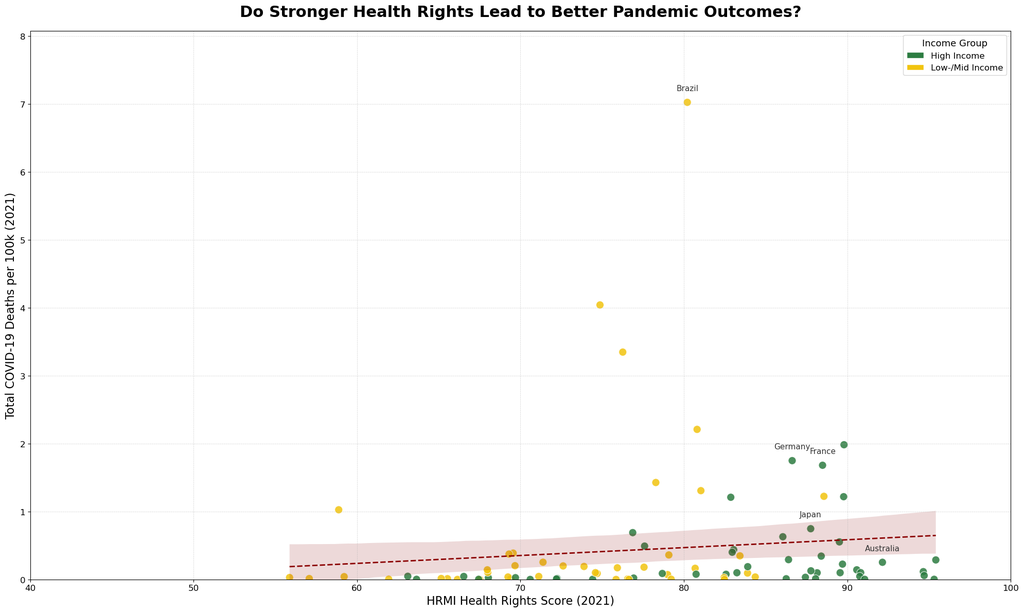

```python
import matplotlib.pyplot as plt
import seaborn as sns
from matplotlib.patches import Patch

# Filter and clean
plot_data = esr_hiy_globalbest[esr_hiy_globalbest['Year'] == 2021].copy()
plot_data = pd.merge(plot_data, country_deaths, on='Country')
plot_data = plot_data.dropna(subset=['HiY_Health_All_GBScore', 'New_deaths', 'High_Income_Country'])
plot_data['High_Income_Country'] = plot_data['High_Income_Country'].astype(bool)

# Visual color map
plot_data['color'] = plot_data['High_Income_Country'].map({True: '#2c7c41', False: '#f1c40f'})  # deep green, gold

# Figure setup
fig, ax = plt.subplots(figsize=(20, 12))

# Scatter plot
ax.scatter(
    plot_data['HiY_Health_All_GBScore'],
    plot_data['New_deaths'] / 100000,
    color=plot_data['color'],
    s=120,
    edgecolor='white',
    linewidth=0.8,
    alpha=0.85
)

# Highlight labels — only selected countries
highlight_countries = {
    'Low': ['Haiti', 'Mozambique', 'Burundi'],
    'Mid': ['India', 'Vietnam', 'El Salvador'],
    'High': ['Germany', 'Japan', 'France', 'Australia', 'United States of America', 'Brazil']
}
for group, countries in highlight_countries.items():
    for country in countries:
        row = plot_data[plot_data['Country'] == country]
        if not row.empty:
            x = row['HiY_Health_All_GBScore'].values[0]
            y = row['New_deaths'].values[0] / 100000
            ax.text(x, y + 0.15, country, fontsize=11, fontweight='medium',
                    ha='center', va='bottom', color='#333333')

# Trendline
sns.regplot(
    data=plot_data,
    x='HiY_Health_All_GBScore',
    y=plot_data['New_deaths'] / 100000,
    scatter=False,
    ax=ax,
    color='darkred',
    line_kws={'linestyle': '--', 'linewidth': 2}
)

# Styling
ax.set_title("Do Stronger Health Rights Lead to Better Pandemic Outcomes?", fontsize=22, weight='bold', pad=20)
ax.set_xlabel("HRMI Health Rights Score (2021)", fontsize=16)
ax.set_ylabel("Total COVID-19 Deaths per 100k (2021)", fontsize=16)
ax.set_xlim(40, 100)
ax.set_ylim(0, plot_data['New_deaths'].max() / 100000 * 1.15)
ax.tick_params(axis='both', labelsize=12)
ax.grid(True, linestyle='--', linewidth=0.5, alpha=0.6)

# Legend
legend_elements = [
    Patch(facecolor='#2c7c41', edgecolor='white', label='High Income'),
    Patch(facecolor='#f1c40f', edgecolor='white', label='Low-/Mid Income')
]
ax.legend(handles=legend_elements, title="Income Group", fontsize=12, title_fontsize=13, loc='upper right')

# Save option (if needed)
# plt.savefig("HRMI_vs_COVIDDeaths.png", dpi=300, bbox_inches='tight')

plt.tight_layout()
plt.show()
```

This figure compares health rights scores in 2021 (from the HRMI dataset) to total COVID-19 deaths per 100K (from the external WHO dataset) for each country. Data points for high-income countries are colored green, whereas data points for low-income countries are colored yellow. The dashed red line is a trendline that fits a linear regression model for the health right scores and COVID-19 deaths, and the shaded red region is the confidence interval for the model. Select countries are labeled.

### Summary: Evaluating COVID-19 Deaths vs. HRMI Health Rights Performance (2021)

We wanted to see if stronger health systems are able to protect countries during times of crisis.

Methodology: We merged 2021 data from the Human Rights Measurement Initiative (HRMI) — which scores countries on how well they fulfill the right to health given their income — with WHO-reported COVID-19 death rates per 100,000 people. After cross-cleaning country names for consistency, we visualized this relationship to identify patterns in pandemic resilience.

What our data Shows:

2. Countries with mid-level HRMI scores outperformed wealthier peers by executing early, cohesive responses. Nations like Vietnam and Senegal, with moderate HRMI scores (65–75), reported very low COVID-19 mortality.

Analysis: These countries may not have historically maximized health rights, but they acted quickly and decisively during the pandemic. Success was driven by proactive containment, coordinated messaging, and strong community compliance — factors not captured in historical health performance, but essential in acute crises (BMJ Global Health, 2021; Nature, 2020).

3. Among high HRMI scorers, trust and policy coordination shaped divergent results. Countries like Canada and South Korea, also top HRMI performers, experienced far fewer deaths than peers like the U.S.

Analysis: These governments deployed centralized public health campaigns, clear risk communication, and consistent containment policies. This led to higher compliance and lower mortality, despite similar starting points. This reinforces research from Health Affairs (2021) that institutional trust is critical in emergencies.

4. HRMI performance is national — but health outcomes weren’t. The HRMI score does not account for within-country inequities, which shaped real-world mortality.

Analysis: In the U.S., COVID-19 death rates were 2–3x higher for Black and Indigenous populations than for white Americans. In the UK, low-income and racial minority communities suffered higher exposure and fatality rates. These disparities are invisible in national-level scores — yet deeply impacted outcomes.

High health system performance (as measured by HRMI) did not consistently translate into lower mortality. Instead, real-time governance, trust, and response agility mattered more than historical capability.

# Insight 3: Comparing Health Right to Education by Income and Region during COVID-19

Insight Summary: Lower-income countries experienced much more dramatic changes in secondary education enrollment rates during COVID-19 than higher-income countries. On a broader level, most world regions experienced increases in enrollment rates alongside decreases in health right scores during COVID-19, suggesting that a general pattern of educational continuity during periods of health-related stress coexists alongside wealth-based differences in response.

## Education Right: Secondary Education Enrollment Rate Data by Income

We decided to use secondary education enrollment rates to explore the right to education because out of the 7 indicators of right to education, the total net upper secondary school enrollment rate was the only indicator that was measured for both low/middle income and high income assessment standards.

### Preparing the data

```python
# List of 63 valid countries that overlapped WHO and ESR (Have some data from 2019-2021)
countries_of_interest = [
    'Afghanistan', 'Albania', 'Algeria', 'Argentina', 'Australia', 'Austria', 'Bangladesh', 'Belgium', 'Brazil', 'Canada', 'Chile', 'China', 'Colombia', 'Czechia', 'Denmark', 'Dominican Republic', 'Ecuador', 'Egypt', 'Ethiopia', 'Finland', 'France', 'Germany', 'Greece', 'Hungary', 'India', 'Indonesia', 'Iran (Islamic Republic of)', 'Iraq', 'Ireland', 'Israel', 'Italy', 'Japan', 'Jordan', 'Kenya', 'Malaysia', 'Mexico', 'Morocco', 'New Zealand', 'Nigeria', 'Norway', 'Pakistan', 'Peru', 'Philippines', 'Poland', 'Portugal', 'Republic of Korea', 'Romania', 'Russian Federation', 'South Africa', 'Spain', 'Sri Lanka', 'Sweden', 'Switzerland', 'Thailand', 'Tunisia', 'Türkiye', 'Ukraine', 'United Arab Emirates', 'United Kingdom', 'United States of America', 'Viet Nam', 'Zambia', 'Zimbabwe'
]

# Filter for countries
edu_df = esr_hiy_globalbest[esr_hiy_globalbest['Country'].isin(countries_of_interest)].copy()

# Only keep enrollment data
edu_df = edu_df[['Country', 'Year', 'TotNetUpSecEn_All_MRValue', 'High_Income_Country']].dropna(subset=['TotNetUpSecEn_All_MRValue'])

# Add income group label
edu_df['Income_Group'] = edu_df['High_Income_Country'].map({1: 'High', 0: 'Low/Middle'})

# Filter df to only the countries of interest
df_interest = edu_df[edu_df['Country'].isin(countries_of_interest)].copy()


# Only keep rows with non-missing enrollment data
df_interest = df_interest.dropna(subset=['TotNetUpSecEn_All_MRValue'])

# Now, find countries with data for all three years (2019, 2020, 2021)
years_needed = {2019, 2020, 2021}
country_years = df_interest.groupby('Country')['Year'].apply(set)

# Select only countries with all three years
valid_countries = country_years[country_years.apply(lambda x: years_needed.issubset(x))].index.tolist()

print("Countries with enrollment data for all years 2019, 2020, and 2021:")
print(valid_countries)
print(f"\nCount: {len(valid_countries)}")

# Filter df_interest to only these valid countries and years
df_valid = df_interest[
    (df_interest['Country'].isin(valid_countries)) &
    (df_interest['Year'].isin([2019, 2020, 2021]))
].copy()
```

```
Countries with enrollment data for all years 2019, 2020, and 2021:
['Afghanistan', 'Albania', 'Argentina', 'Australia', 'Austria', 'Bangladesh', 'Belgium', 'Brazil', 'Canada', 'Chile', 'Colombia', 'Czechia', 'Denmark', 'Dominican Republic', 'Ecuador', 'Ethiopia', 'Finland', 'France', 'Germany', 'Greece', 'Hungary', 'India', 'Indonesia', 'Ireland', 'Israel', 'Italy'…

Count: 50
```

### Analysis of Dramatic Change in Enrollment Rates

#### 1. Calculate the Change in Enrollment Rate (2021 - 2019) for Each Country

```python
# Pivot so each country has a column for 2019 and 2021 enrollment
pivot = df_valid.pivot_table(index='Country', columns='Year', values='TotNetUpSecEn_All_MRValue')

# Calculate the change
pivot['change'] = pivot[2021] - pivot[2019]

# Merge with income group info
income_map = df_valid[['Country', 'Income_Group']].drop_duplicates().set_index('Country')
pivot['Income_Group'] = income_map['Income_Group']

# Print the table
print("Enrollment rate in 2019 and 2021, and the change (2021-2019):")
print(pivot[[2019, 2021, 'change', 'Income_Group']].head())
```

```
Enrollment rate in 2019 and 2021, and the change (2021-2019):
Year             2019      2021   change Income_Group
Country
Afghanistan  45.45444  45.45444  0.00000   Low/Middle
Albania      86.70620  86.76399  0.05779   Low/Middle
Argentina    91.39246  96.01202  4.61956   Low/Middle
Australia    96.76626  95.49858 -1.26768         High
Austria      92.95864  93.51477  0.55613         High
```

#### 2. Find Countries with the Most Dramatic Changes

```python
# For high-income: sort by absolute value of change
high_drama = pivot[pivot['Income_Group'] == 'High'].copy()
high_drama['abs_change'] = high_drama['change'].abs()
high_drama_sorted = high_drama.sort_values('abs_change', ascending=False)

print("\nHigh-income countries with most dramatic enrollment changes (2019-2021):")
print(high_drama_sorted[[2019, 2021, 'change']].head(5))

# For low/middle-income: sort by absolute value of change
lowmid_drama = pivot[pivot['Income_Group'] == 'Low/Middle'].copy()
lowmid_drama['abs_change'] = lowmid_drama['change'].abs()
lowmid_drama_sorted = lowmid_drama.sort_values('abs_change', ascending=False)

print("\nLow/middle-income countries with most dramatic enrollment changes (2019-2021):")
print(lowmid_drama_sorted[[2019, 2021, 'change']].head(5))
```

```
High-income countries with most dramatic enrollment changes (2019-2021):
Year                2019      2021   change
Country
Greece          96.01050  93.97881 -2.03169
Denmark         91.21514  93.00616  1.79102
United Kingdom  96.62211  94.83688 -1.78523
Hungary         88.07883  86.63663 -1.44220
Norway          93.31033  94.65299  1.34266

Low/middle-income countries with most dramatic enrollment changes (2019-2021):
Year                    2019      2021    change
Country
Ukraine             89.32571  78.31804 -11.00767
South Africa        86.10497  94.43680   8.33183
India               50.92256  58.90580   7.98324
Dominican Republic  77.98333  70.18300  -7.80033
Jordan              55.01503  62.19394   7.17891
```

#### 3. Graph: Dramatic change in Enrollment Rate (High-Income vs Low/Middle-Income)

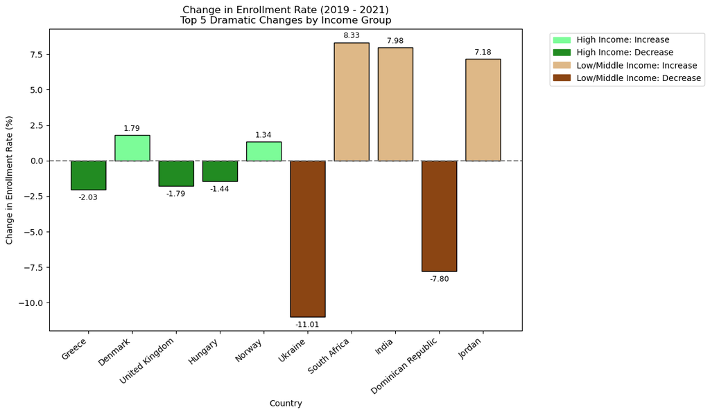

```python
import pandas as pd

# Combine both groups for plotting
plot_df = pd.concat([
    high_drama_sorted.head(5)[['change']].assign(Group='High Income'),
    lowmid_drama_sorted.head(5)[['change']].assign(Group='Low/Middle Income')
])

plot_df = plot_df.reset_index().rename(columns={'index': 'Country'})

# Assign custom colors
def get_bar_color(row):
    if row['Group'] == 'High Income':
        return '#7CFC98' if row['change'] > 0 else '#228B22'  # light green, dark green
    else:
        return '#DEB887' if row['change'] > 0 else '#8B4513'  # light brown, dark brown

plot_df['bar_color'] = plot_df.apply(get_bar_color, axis=1)


plt.figure(figsize=(12, 7))  # Make the plot wider
bars = plt.bar(
    plot_df['Country'],
    plot_df['change'],
    color=plot_df['bar_color'],
    edgecolor='black'
)
plt.axhline(0, color='gray', linestyle='--')
plt.title('Change in Enrollment Rate (2019 - 2021)\nTop 5 Dramatic Changes by Income Group')
plt.ylabel('Change in Enrollment Rate (%)')
plt.xlabel('Country')
plt.xticks(rotation=40, ha='right')

# Annotate bars with different offsets for positive/negative
for bar, value in zip(bars, plot_df['change']):
    if value > 0:
        plt.annotate(f"{value:.2f}", (bar.get_x() + bar.get_width() / 2., value),
                     ha='center', va='bottom', fontsize=9, color='black', xytext=(0, 3), textcoords='offset points')
    else:
        plt.annotate(f"{value:.2f}", (bar.get_x() + bar.get_width() / 2., value),
                     ha='center', va='top', fontsize=9, color='black', xytext=(0, -5), textcoords='offset points')

# Custom legend
import matplotlib.patches as mpatches
legend_patches = [
    mpatches.Patch(color='#7CFC98', label='High Income: Increase'),
    mpatches.Patch(color='#228B22', label='High Income: Decrease'),
    mpatches.Patch(color='#DEB887', label='Low/Middle Income: Increase'),
    mpatches.Patch(color='#8B4513', label='Low/Middle Income: Decrease')
]
plt.legend(handles=legend_patches, bbox_to_anchor=(1.05, 1), loc='upper left')

plt.tight_layout()
plt.show()
```

This figure shows the 5 high-income countries and 5 low/middle-income countries with the most dramatic changes in secondary education enrollment rate for their income group from 2019 (pre-COVID) to 2021 (post-COVID). The high-income countries (Greece, Denmark, the United Kingdom, Hungary, and Norway) are shaded dark green to represent decreases in enrollment rate from 2019 to 2021, and light green to represent increases. The low/middle-income countries (Ukraine, South Africa, India, the Dominican Republic, and Jordan) are shaded dark brown to represent decreases in enrollment rate and light brown to represent increases.

#### Summary on Education Right Findings: Enrollment Rate Changes (2019–2021)

Our analysis of upper secondary enrollment rates across selected high-income and low/middle-income countries during the COVID-19 pandemic reveals several surprising patterns:

- Unexpected Successes in Low/Middle-Income Countries: Countries such as South Africa, India, and Jordan achieved substantial increases in enrollment rates, defying expectations that lower income would necessarily mean greater educational disruption during the pandemic.
- Severe Declines Not Limited to the Poor: Ukraine and the Dominican Republic, both low/middle-income, experienced the largest drops, but declines were also present in high-income countries, highlighting that wealth alone did not guarantee resilience.
- Policy and Context Matter: These findings suggest that national policy responses, adaptability, and local context played a more decisive role in educational continuity than income group alone.
  - It is also important to keep in mind that other external factors may have played a role in educational continuity. For example, during this time period, Ukraine faced not only COVID-19 but also continued conflict with Russia that preceded the full-scale Russian invasion of Ukraine in early 2022. This could have negatively affected their steep drop in secondary education enrollment rate.

**Key Takeaway:** The COVID-19 pandemic was a stress test for education systems worldwide. Our results show that resilience and recovery in enrollment rates depended not just on a country’s wealth, but on its ability to adapt, innovate, and support students through crisis.

## Comparing Secondary Education Enrollment Rates to Health Scores by Region

### Preparing the data for visualization

```python
# filter datasets to only include high income and hrmi_lo to only include low income
hrmi_hi = esr_hiy_globalbest[esr_hiy_globalbest['High_Income_Country'] == 1]
hrmi_lo = esr_lmy_globalbest[esr_lmy_globalbest['High_Income_Country'] == 0]
# Combine HRMI with health AND 2ndary edu enroll rate
hi_edu = hrmi_hi[['Country', 'Year', 'HiY_Health_All_GBScore', 'TotNetUpSecEn_All_MRValue']].rename(columns={'HiY_Health_All_GBScore': 'Health_GBScore', 'TotNetUpSecEn_All_MRValue': 'Enrollment_Rate'})
lo_edu = hrmi_lo[['Country', 'Year', 'LMY_Health_All_GBScore', 'TotNetUpSecEn_All_MRValue']].rename(columns={'LMY_Health_All_GBScore': 'Health_GBScore', 'TotNetUpSecEn_All_MRValue' : 'Enrollment_Rate'})
hrmi_edu = pd.concat([hi_edu, lo_edu], ignore_index=True)

# Name mapping
hrmi_edu['Country'] = hrmi_edu['Country'].replace(name_mapping)

# cut to only "pre-covid" (2019) and "post-covid" (2021)
hrmi_edu_covid = hrmi_edu[hrmi_edu['Year'].isin([2019, 2021])]

# remove any countries that have no health score data or enrollment rate data
hrmi_edu_covid = hrmi_edu_covid.groupby('Country').filter(lambda x: x['Health_GBScore'].notna().any())
hrmi_edu_covid = hrmi_edu_covid.groupby('Country').filter(lambda x: x['Enrollment_Rate'].notna().any())

# categorize by region
hrmi_edu_covid['Region'] = hrmi_edu_covid['Country'].map(country_to_region)
```

```python
# Changes in health score and enrollment rate for each country
# Pivot to get scores side by side per country
pivoted = hrmi_edu_covid.pivot(index='Country', columns='Year', values=['Health_GBScore', 'Enrollment_Rate'])

# Flatten MultiIndex columns
pivoted.columns = ['Health_2019', 'Health_2021', 'Edu_2019', 'Edu_2021']
pivoted = pivoted.reset_index()

# Calculate change from 2019 to 2021
pivoted['Health_Change'] = pivoted['Health_2021'] - pivoted['Health_2019']
pivoted['Edu_Change'] = pivoted['Edu_2021'] - pivoted['Edu_2019']

# Merge with region info
region_info = hrmi_edu_covid[['Country', 'Region']].drop_duplicates()
pivoted = pivoted.merge(region_info, on='Country', how='left')

# Average changes by region
region_changes = pivoted.groupby('Region')[['Health_Change', 'Edu_Change']].mean().reset_index()
```

### Graph: Average change in secondary education enrollment rate vs health scores by region (2019-2021)

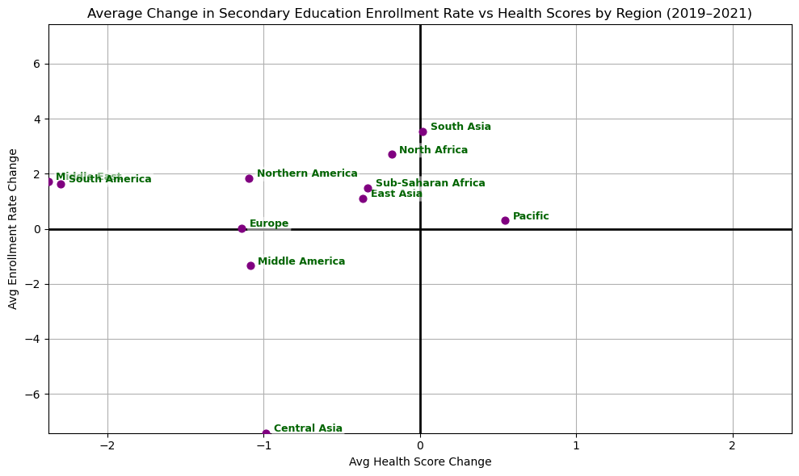

```python
# plot that shows change in enrollment rate from 2019-2021 vs change in health score from 2019-2021
plt.figure(figsize=(10, 6))
plt.scatter(region_changes['Health_Change'], region_changes['Edu_Change'], color = 'purple', s = 40, zorder = 4)

# Add labels
for _, row in region_changes.iterrows():
    plt.text(
    row['Health_Change'] + 0.05, row['Edu_Change'] + 0.05, row['Region'],
    fontsize=9,
    fontweight='bold',
    color='darkgreen',
    bbox=dict(facecolor='white', edgecolor='none', alpha=0.5, boxstyle='round,pad=0.2'),
    zorder = 3
)

#visually center 0
xmax = max(abs(region_changes['Health_Change'].min()), abs(region_changes['Health_Change'].max()))
ymax = max(abs(region_changes['Edu_Change'].min()), abs(region_changes['Edu_Change'].max()))

plt.xlim(-xmax, xmax)
plt.ylim(-ymax, ymax)

plt.axhline(0, color='black', linewidth=2, zorder = 2)
plt.axvline(0, color='black', linewidth=2, zorder = 2)
plt.title('Average Change in Secondary Education Enrollment Rate vs Health Scores by Region (2019–2021)')
plt.xlabel('Avg Health Score Change')
plt.ylabel('Avg Enrollment Rate Change')
plt.grid(True, zorder = 1)
plt.tight_layout()
plt.show()
```

#### Summary

This graph compares changes in average health score vs changes in average secondary education enrollment rate by region from 2019-2021 in order to further explore the relationship between health and education during the COVID-19 pandemic.

The graph is split into four quadrants:

- Top Left: Decrease in Health Score, Increase in Enrollment Rate
- Regions: Middle East, South America, Europe, Northern America, East Asia, Sub-Saharan Africa, North Africa
- The majority of the regions fall into this category, experiencing a decrease in health score as well as an increase in enrollment rate from pre- to post-COVID. This may indicate that these countries' education systems were able to withstand the effects of COVID, health-related and otherwise.
- Top Right: Increase in Health Score, Increase in Enrollment Rate
- Regions: South Asia, Pacific
- These regions experienced an increase in health score from pre- to post-COVID alongside an increase in enrollment rate, suggesting that they may have responded to COVID more effectively than other regions.
- Bottom Left: Decrease in Health Score, Decrease in Enrollment Rate
- Regions: Middle America, Central Asia
- These regions experienced a decrease in both health score and enrollment rate, possibly indicating that these countries' schooling systems were not equipped for the impacts of COVID-19.
- Bottom Right: Increase in Health Score, Decrease in Enrollment Rate
- Regions: None
- No regions fell into this category, suggesting that better response to COVID-19 (here indicated by a positive change in health score during that period) did not come at the expense of education.

Combined with the analysis of education rights and income group, it is interesting to note that:

1. The 5 high-income countries with the most dramatic enrollment rate changes are *all in Europe*. The fact that Europe's average change in enrollment rate was near 0 is reasonable, as 2 of those countries experienced increases while the other 3 experienced decreases.
2. The 5 low-income countries with the most dramatic enrollment rate changes are *all in different regions*. This further points to the interaction between the global effects of COVID and the individual circumstances of various regions and countries at the time.

**Key Takeaway:** Regional differences in COVID-19 preparedness and education systems affected countries' ability to respond to and withstand the global crisis.

# Exhibits

Extra figures we created along the way to help us understand and analyze the data (not in any specific insight)

#### USING Pivot Tables and Panel Data for Pattern Analysis

```
Pivot Table for High-Income Countries Health Scores:
Year                  1990       1991       1992       1993       1994  \
Country
Austria          82.894577  83.369338  83.147116  83.931730  84.150176
Germany          82.010228  82.166659  82.802819  82.923920  83.049081
Greece           84.513904  84.460872  84.073076  85.152753  84.919921
Ireland          82.625909  82.682639  83.339145  82.995669  83.829886
Italy            84.020936  83.912061  84.644423  84.571384  84.665752
Latvia                 NaN        NaN        NaN        NaN        NaN
Netherlands            NaN        NaN        NaN        NaN        NaN
Norway           84.540041  84.896404  85.702834  85.431735  86.274449
Slovak Republic        NaN        NaN  78.534000  78.829981  79.349073
Sweden           87.409632  87.445358  87.773006  88.229159  89.360887

Year                  1995       1996       1997       1998       1999  ...  \
Country                                                                 ...
Austria          84.312319  84.363344  84.359674  84.775684  84.203376  ...
Germany          83.064054  83.330712  83.750581  83.706425  83.759145  ...
Greece           84.205244  84.371143  84.352933  83.700922  82.788884  ...
Ireland          82.260537  82.963694  82.683557  83.092184  82.700972  ...
Italy            85.056277  85.480639  85.748462  85.778956  85.476245  ...
Latvia           78.191547  79.798006  80.338778  79.711011  80.711987  ...
Netherlands      81.081851  81.329975  81.965610  81.961931  81.668887  ...
Norway           86.305719  86.808116  86.796040  87.156277  86.703722  ...
Slovak Republic  78.927482  79.186678  79.518860  79.029581  79.218935  ...
Sweden           89.085318  89.837880  89.938264  89.917527  90.254023  ...

Year                  2012       2013       2014       2015       2016  \
Country
Austria          86.991142  87.292332  88.154792  87.961498  88.526499
Germany          86.541983  87.078855  87.081486  86.752802  87.039534
Greece           83.363118  85.501750  85.297953  84.474649  84.730443
Ireland          89.559240  89.393278  89.448555  88.760091  88.698638
Italy            89.012278  89.416238  89.708347  89.028682  89.552812
Latvia           84.366125  84.841534  85.234304  85.279700  85.555690
Netherlands      88.242574  88.216425  89.061481  88.907548  89.486678
Norway           91.573060  92.075584  92.640284  93.104244  92.853451
Slovak Republic  81.071110  81.845820  81.987206  81.739859  82.639545
Sweden           93.997833  94.085272  93.979756  94.138273  94.036145

```

[output cut: 113 more lines]

```

      YoY_Change  Growth_Rate
96           NaN          NaN
97           NaN          NaN
98           NaN          NaN
99           NaN          NaN
100          NaN          NaN
...          ...          ...
5723    0.030992     0.000441
5724    0.115376     0.001640
5725    1.220884     0.017330
5726   -0.401537    -0.005603
5727   -0.490587    -0.006884

[320 rows x 6 columns]
```

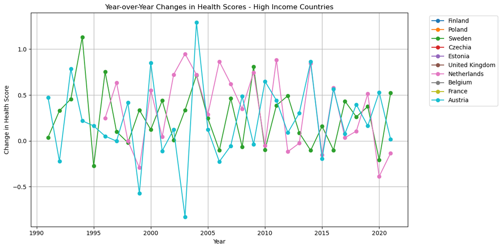

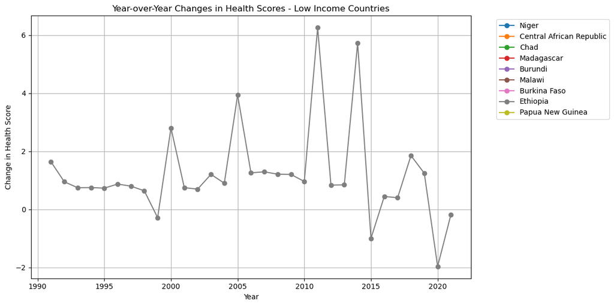

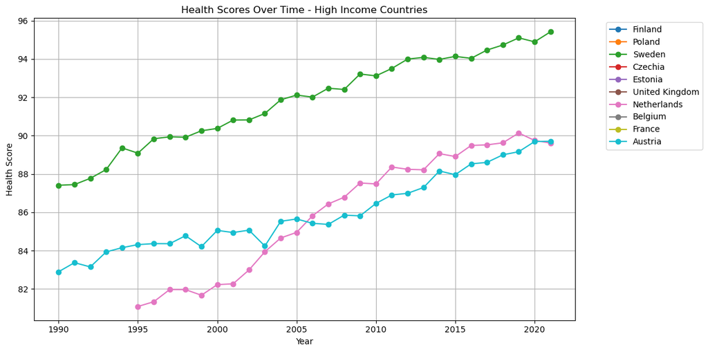

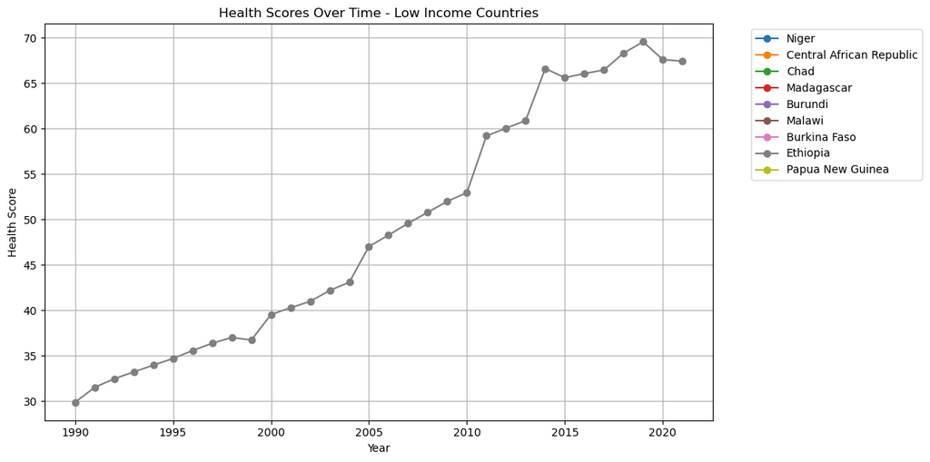

```
Summary of Health Scores by Year - High Income Countries:
      count       mean       std        min        25%        50%        75%  \
Year
1990    7.0  84.002175  1.791230  82.010228  82.760243  84.020936  84.526972
1991    7.0  84.133333  1.744708  82.166659  83.025989  83.912061  84.678638
1992    8.0  83.752052  2.660251  78.534000  83.061042  83.706111  84.909026
1993    8.0  84.008292  2.685698  78.829981  82.977732  84.251557  85.222499
1994    8.0  84.449903  2.832699  79.349073  83.634684  84.407964  85.258553
1995   10.0  83.249035  3.311236  78.191547  81.376523  83.634649  84.870288
1996   10.0  83.747019  3.219112  79.186678  81.738405  83.847028  85.203265
1997   10.0  83.945276  3.087269  79.518860  82.145097  84.051757  85.401265
1998   10.0  83.883050  3.280630  79.029581  82.244494  83.703674  85.528138
1999   10.0  83.748618  3.168029  79.218935  81.926908  83.274015  85.158028
2000   10.0  84.193229  3.180640  79.361884  82.350766  83.997229  85.473128
2001   10.0  84.309456  3.340327  79.522480  82.409922  84.281524  86.020948
```

[output cut: 126 more lines]

```python
# 1. First, let's create a pivot table to see health scores across countries and years
# This is from Lecture 17 technique

# For high-income countries
high_income_pivot = pd.pivot_table(high_income_health,
                                 values='HiY_Health_All_GBScore',
                                 index='Country',
                                 columns='Year')

print("Pivot Table for High-Income Countries Health Scores:")
print(high_income_pivot)
print("\n")

# For low-income countries
low_income_pivot = pd.pivot_table(low_income_health,
                                values='LMY_Health_All_GBScore',
                                index='Country',
                                columns='Year')

print("Pivot Table for Low-Income Countries Health Scores:")
print(low_income_pivot)

# 2. From Lecture 18 (Panel Data), let's calculate:
# - Year-over-year changes
# - Growth rates
# - Rolling averages

# For high-income countries
high_income_panel = high_income_health.sort_values(['Country', 'Year'])
high_income_panel['YoY_Change'] = high_income_panel.groupby('Country')['HiY_Health_All_GBScore'].diff()
high_income_panel['Growth_Rate'] = high_income_panel.groupby('Country')['HiY_Health_All_GBScore'].pct_change()

# For low-income countries
low_income_panel = low_income_health.sort_values(['Country', 'Year'])
low_income_panel['YoY_Change'] = low_income_panel.groupby('Country')['LMY_Health_All_GBScore'].diff()
low_income_panel['Growth_Rate'] = low_income_panel.groupby('Country')['LMY_Health_All_GBScore'].pct_change()

print("\nPanel Data Analysis for High-Income Countries:")
print(high_income_panel)
print("\nPanel Data Analysis for Low-Income Countries:")
print(low_income_panel)


# Create separate graphs for high-income and low-income countries

# High Income Countries Graph
plt.figure(figsize=(12, 6))
for country in top_high_income_countries:
    country_data = high_income_panel[high_income_panel['Country'] == country]
    plt.plot(country_data['Year'], country_data['YoY_Change'], marker='o', label=country)
plt.title('Year-over-Year Changes in Health Scores - High Income Countries')
plt.xlabel('Year')
plt.ylabel('Change in Health Score')
plt.legend(bbox_to_anchor=(1.05, 1), loc='upper left')
plt.grid(True)
plt.tight_layout()
plt.show()

# Low Income Countries Graph
plt.figure(figsize=(12, 6))
for country in bottom_income_countries:
    country_data = low_income_panel[low_income_panel['Country'] == country]
    plt.plot(country_data['Year'], country_data['YoY_Change'], marker='o', label=country)
plt.title('Year-over-Year Changes in Health Scores - Low Income Countries')
plt.xlabel('Year')
plt.ylabel('Change in Health Score')
plt.legend(bbox_to_anchor=(1.05, 1), loc='upper left')
plt.grid(True)
plt.tight_layout()
plt.show()

# Let's also add graphs showing the actual health scores (not just changes)

# High Income Countries Health Scores
plt.figure(figsize=(12, 6))
for country in top_high_income_countries:
    country_data = high_income_panel[high_income_panel['Country'] == country]
    plt.plot(country_data['Year'], country_data['HiY_Health_All_GBScore'], marker='o', label=country)
plt.title('Health Scores Over Time - High Income Countries')
plt.xlabel('Year')
plt.ylabel('Health Score')
plt.legend(bbox_to_anchor=(1.05, 1), loc='upper left')
plt.grid(True)
plt.tight_layout()
plt.show()

# Low Income Countries Health Scores
plt.figure(figsize=(12, 6))
for country in bottom_income_countries:
    country_data = low_income_panel[low_income_panel['Country'] == country]
    plt.plot(country_data['Year'], country_data['LMY_Health_All_GBScore'], marker='o', label=country)
plt.title('Health Scores Over Time - Low Income Countries')
plt.xlabel('Year')
plt.ylabel('Health Score')
plt.legend(bbox_to_anchor=(1.05, 1), loc='upper left')
plt.grid(True)
plt.tight_layout()
plt.show()

# Add summary statistics for better understanding
print("\nSummary of Health Scores by Year - High Income Countries:")
print(high_income_panel.groupby('Year')['HiY_Health_All_GBScore'].describe())

print("\nSummary of Health Scores by Year - Low Income Countries:")
print(low_income_panel.groupby('Year')['LMY_Health_All_GBScore'].describe())
```